# Untitled

vijendra

July 19, 2018

# AIM

- To predict whether the credit profile of a client is good or bad.
- To analyse the imformation of our past customers and build a machine learning model to predict with some confidence whether the new applicants will turn out be a defaulter.

# ABOUT DATA

- The dataset was collected by Prof. Hans Hofmann of Hamburg University in 1994. This dataset is now publicaly available at UCI ML Repository. It can be downloaded from here.
- The dataset contains 1000 samples with 21 features 14 of which are categorical and 7 are numeric. It contains no missing data. Some basic transformations were applied on the dataset such as coding the classes in categorical variables. For eg, Status was coded into A11 & A12
- The attributes(features) are as follows :
  - check.acc.: (qualitative) Status of existing checking account
  - Duration: (numerical) Duration in month
  - Cred_hist.: (qualitative) Credit history
  - Purpose: (qualitative) Purpose of loan
  - Cred_amt: (numerical) Credit amount
  - saving_bond: (qualitative) Savings account/bonds
  - employ_since: (qualitative) Present employment since
  - Installment_rate: (numerical) Installment rate in percentage of disposable income
  - personal_status: (qualitative) Personal status and sex
  - other_debtors: (qualitative) Other debtors / guarantors
  - residence_since: (numerical) Present residence since
  - property: (qualitative) Property
  - age: (numerical) Age in years
  - other_install_plans: (qualitative) Other installment plans
  - housing: (qualitative) Housing
  - no.of_exist_credit: (numerical) Number of existing credits at this bank
  - job: (qualitative) Job
  - dependents: (numerical) Number of people being liable to provide maintenance for
  - telephone: (qualitative) Telephone
  - foreign_worker: (qualitative) foreign worker
- The target variable is binary classification:
  - 1 - Good Credit
  - 0 - Bad Credit

# DATA PREPROCESSING

We need to assign attribute names to the data set.

```r
my_data <- read.table("german.data",sep="",header=FALSE, col.names = c("check.acc ","duration","cred_hist ","Purpose","Cred_amt","saving_bond","employ_since","Installment_rate","personal_status","other_debtors","residence_since","property ","age","other_install_plans","housing ","no.of_exist_cred","job","dependents","telephone","foreign_worker","status"),stringsAsFactors = FALSE)
```

Check missing data if any:

```r
head(my_data)
```

|  | check.acc. | duration | cred_hist. | Purpose | Cred_amt | saving_bond | employ_since | Installment_rate | personal_status | other_debtors | residence_since | property. | age | other_install_plans | housing. | no.of_exist_cred | job | dependents | telephone | foreign_worker | status |
| --- | --- | --- | --- | --- | --- | --- | --- | --- | --- | --- | --- | --- | --- | --- | --- | --- | --- | --- | --- | --- | --- |
| 1 | A11 | 6 | A34 | A43 | 1169 | A65 | A75 | 4 | A93 | A101 | 4 | A121 | 67 | A143 | A152 | 2 | A173 | 1 | A192 | A201 | 1 |
| 2 | A12 | 48 | A32 | A43 | 5951 | A61 | A73 | 2 | A92 | A101 | 2 | A121 | 22 | A143 | A152 | 1 | A173 | 1 | A191 | A201 | 2 |
| 3 | A14 | 12 | A34 | A46 | 2096 | A61 | A74 | 2 | A93 | A101 | 3 | A121 | 49 | A143 | A152 | 1 | A172 | 2 | A191 | A201 | 1 |
| 4 | A11 | 42 | A32 | A42 | 7882 | A61 | A74 | 2 | A93 | A103 | 4 | A122 | 45 | A143 | A153 | 1 | A173 | 2 | A191 | A201 | 1 |
| 5 | A11 | 24 | A33 | A40 | 4870 | A61 | A73 | 3 | A93 | A101 | 4 | A124 | 53 | A143 | A153 | 2 | A173 | 2 | A191 | A201 | 2 |
| 6 | A14 | 36 | A32 | A46 | 9055 | A65 | A73 | 2 | A93 | A101 | 4 | A124 | 35 | A143 | A153 | 1 | A172 | 2 | A192 | A201 | 1 |

```r
sum(is.na(my_data))
```

```
## [1] 0
```

Replacing the bad credit status with 0 value.

```r
my_data$status[my_data$status==2]<-0
table(my_data$status)
```

```
##
##   0   1
## 300 700
```

```r
head(my_data)
```

|  | check.acc. | duration | cred_hist. | Purpose | Cred_amt | saving_bond | employ_since | Installment_rate | personal_status | other_debtors | residence_since | property. | age | other_install_plans | housing. | no.of_exist_cred | job | dependents | telephone | foreign_worker | status |
| --- | --- | --- | --- | --- | --- | --- | --- | --- | --- | --- | --- | --- | --- | --- | --- | --- | --- | --- | --- | --- | --- |
| 1 | A11 | 6 | A34 | A43 | 1169 | A65 | A75 | 4 | A93 | A101 | 4 | A121 | 67 | A143 | A152 | 2 | A173 | 1 | A192 | A201 | 1 |
| 2 | A12 | 48 | A32 | A43 | 5951 | A61 | A73 | 2 | A92 | A101 | 2 | A121 | 22 | A143 | A152 | 1 | A173 | 1 | A191 | A201 | 0 |
| 3 | A14 | 12 | A34 | A46 | 2096 | A61 | A74 | 2 | A93 | A101 | 3 | A121 | 49 | A143 | A152 | 1 | A172 | 2 | A191 | A201 | 1 |
| 4 | A11 | 42 | A32 | A42 | 7882 | A61 | A74 | 2 | A93 | A103 | 4 | A122 | 45 | A143 | A153 | 1 | A173 | 2 | A191 | A201 | 1 |
| 5 | A11 | 24 | A33 | A40 | 4870 | A61 | A73 | 3 | A93 | A101 | 4 | A124 | 53 | A143 | A153 | 2 | A173 | 2 | A191 | A201 | 0 |
| 6 | A14 | 36 | A32 | A46 | 9055 | A65 | A73 | 2 | A93 | A101 | 4 | A124 | 35 | A143 | A153 | 1 | A172 | 2 | A192 | A201 | 1 |

Check the structure and the summary of the data

```r
str(my_data)
```

```
## 'data.frame':    1000 obs. of  21 variables:
##  $ check.acc.         : chr  "A11" "A12" "A14" "A11" ...
##  $ duration           : int  6 48 12 42 24 36 24 36 12 30 ...
##  $ cred_hist.         : chr  "A34" "A32" "A34" "A32" ...
##  $ Purpose            : chr  "A43" "A43" "A46" "A42" ...
##  $ Cred_amt           : int  1169 5951 2096 7882 4870 9055 2835 6948 3059 5234 ...
##  $ saving_bond        : chr  "A65" "A61" "A61" "A61" ...
##  $ employ_since       : chr  "A75" "A73" "A74" "A74" ...
##  $ Installment_rate   : int  4 2 2 2 3 2 3 2 2 4 ...
##  $ personal_status    : chr  "A93" "A92" "A93" "A93" ...
##  $ other_debtors      : chr  "A101" "A101" "A101" "A103" ...
##  $ residence_since    : int  4 2 3 4 4 4 4 2 4 2 ...
##  $ property.          : chr  "A121" "A121" "A121" "A122" ...
##  $ age                : int  67 22 49 45 53 35 53 35 61 28 ...
##  $ other_install_plans: chr  "A143" "A143" "A143" "A143" ...
##  $ housing.           : chr  "A152" "A152" "A152" "A153" ...
##  $ no.of_exist_cred   : int  2 1 1 1 2 1 1 1 1 2 ...
##  $ job                : chr  "A173" "A173" "A172" "A173" ...
##  $ dependents         : int  1 1 2 2 2 2 1 1 1 1 ...
##  $ telephone          : chr  "A192" "A191" "A191" "A191" ...
##  $ foreign_worker     : chr  "A201" "A201" "A201" "A201" ...
##  $ status             : num  1 0 1 1 0 1 1 1 1 0 ...
```

```r
summary(my_data)
```

```
##   check.acc.           duration     cred_hist.          Purpose
##  Length:1000        Min.   : 4.0   Length:1000        Length:1000
##  Class :character   1st Qu.:12.0   Class :character   Class :character
##  Mode  :character   Median :18.0   Mode  :character   Mode  :character
##                     Mean   :20.9
##                     3rd Qu.:24.0
##                     Max.   :72.0
##     Cred_amt     saving_bond        employ_since       Installment_rate
##  Min.   :  250   Length:1000        Length:1000        Min.   :1.000
##  1st Qu.: 1366   Class :character   Class :character   1st Qu.:2.000
##  Median : 2320   Mode  :character   Mode  :character   Median :3.000
##  Mean   : 3271                                         Mean   :2.973
##  3rd Qu.: 3972                                         3rd Qu.:4.000
##  Max.   :18424                                         Max.   :4.000
##  personal_status    other_debtors      residence_since  property.
##  Length:1000        Length:1000        Min.   :1.000   Length:1000
##  Class :character   Class :character   1st Qu.:2.000   Class :character
##  Mode  :character   Mode  :character   Median :3.000   Mode  :character
##                                        Mean   :2.845
##                                        3rd Qu.:4.000
##                                        Max.   :4.000
##       age        other_install_plans   housing.         no.of_exist_cred
##  Min.   :19.00   Length:1000         Length:1000        Min.   :1.000
##  1st Qu.:27.00   Class :character    Class :character   1st Qu.:1.000
##  Median :33.00   Mode  :character    Mode  :character   Median :1.000
##  Mean   :35.55                                          Mean   :1.407
##  3rd Qu.:42.00                                          3rd Qu.:2.000
##  Max.   :75.00                                          Max.   :4.000
##      job              dependents     telephone         foreign_worker
##  Length:1000        Min.   :1.000   Length:1000        Length:1000
##  Class :character   1st Qu.:1.000   Class :character   Class :character
##  Mode  :character   Median :1.000   Mode  :character   Mode  :character
##                     Mean   :1.155
##                     3rd Qu.:1.000
##                     Max.   :2.000
##      status
##  Min.   :0.0
##  1st Qu.:0.0
##  Median :1.0
##  Mean   :0.7
##  3rd Qu.:1.0
##  Max.   :1.0
```

- Looking at the above summary and structure we can tell that there are 7 numerical attributes (features ) and no missing values in this data set.

# Distribution Plot for the Numerical Data

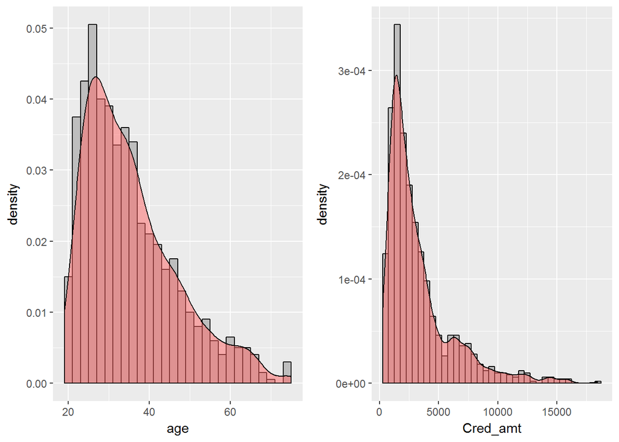

```r
p1 <-ggplot(my_data, aes(x=age)) +geom_histogram(aes(y=..density..),binwidth = 2, colour = "black",fill= "grey")+ geom_density(alpha= 0.5, fill = "#FF6666")
p2 <- ggplot(my_data, aes(x=Cred_amt)) +geom_histogram(aes(y=..density..),binwidth = 500, colour = "black",fill= "grey")+ geom_density(alpha= 0.5, fill = "#FF6666")

grid.arrange(p1,p2,nrow=1)
```

- The graphs depicts that the data are right skewed for age and cred amounts
- The age data is dense in 25-40 range that means major data comes from working class.

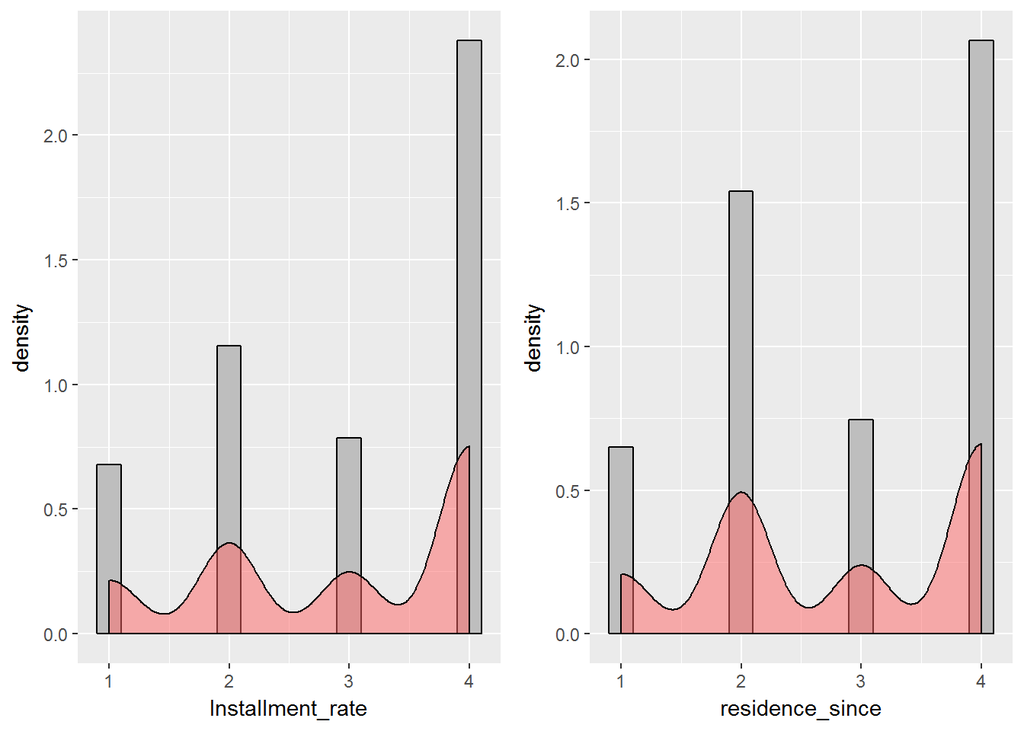

```r
p3 <- ggplot(my_data, aes(x= Installment_rate)) +geom_histogram(aes(y=..density..),binwidth = .2, colour = "black",fill= "grey")+ geom_density(alpha= 0.5, fill = "#FF6666")
p4 <- ggplot(my_data, aes(x= residence_since)) +geom_histogram(aes(y=..density..),binwidth = .2, colour = "black",fill= "grey")+ geom_density(alpha= 0.5, fill = "#FF6666")

grid.arrange(p3,p4,nrow=1)
```

- Graphs are multimodal means higher chances that data does not follow normal distribution

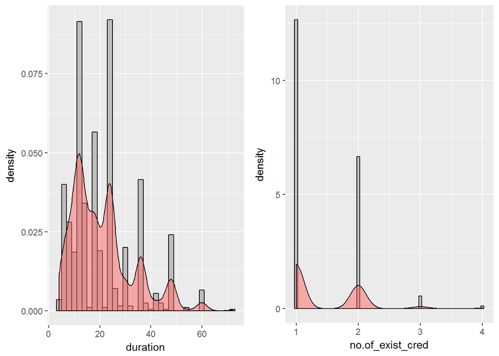

```r
p5 <- ggplot(my_data, aes(x= duration)) +geom_histogram(aes(y=..density..),binwidth = 2, colour = "black",fill= "grey")+ geom_density(alpha= 0.5, fill = "#FF6666")
p6 <- ggplot(my_data, aes(x = no.of_exist_cred)) +geom_histogram(aes(y=..density..),binwidth = 0.05, colour = "black",fill= "grey")+ geom_density(alpha= 0.5, fill = "#FF6666")

grid.arrange(p5,p6,nrow=1)
```

- Graphs are multimodal and slightly right skewed.

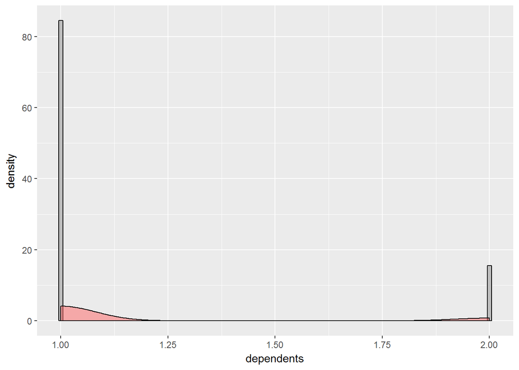

```r
ggplot(my_data, aes(x= dependents)) +geom_histogram(aes(y=..density..),binwidth = 0.01, colour = "black",fill= "grey")+ geom_density(alpha= 0.5, fill = "#FF6666")
```

# Countplot for categorical data

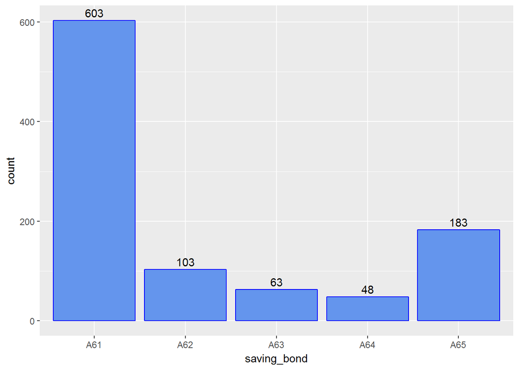

```r
ggplot(my_data,aes(x=saving_bond))+geom_bar(stat = "count",fill= "cornflowerblue",col="blue")+geom_text(stat='count',aes(label = ..count..),vjust = -0.4)
```

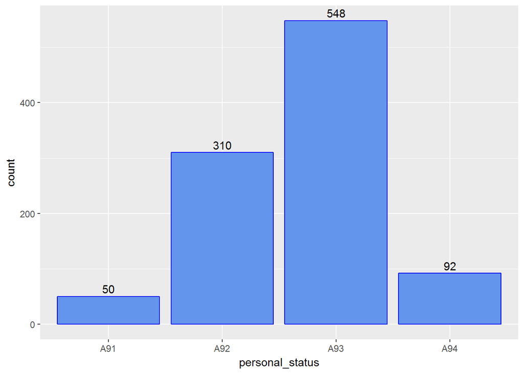

```r
ggplot(my_data,aes(x=personal_status))+geom_bar(stat = "count",fill= "cornflowerblue",col="blue")+geom_text(stat='count',aes(label = ..count..),vjust = -0.4)
```

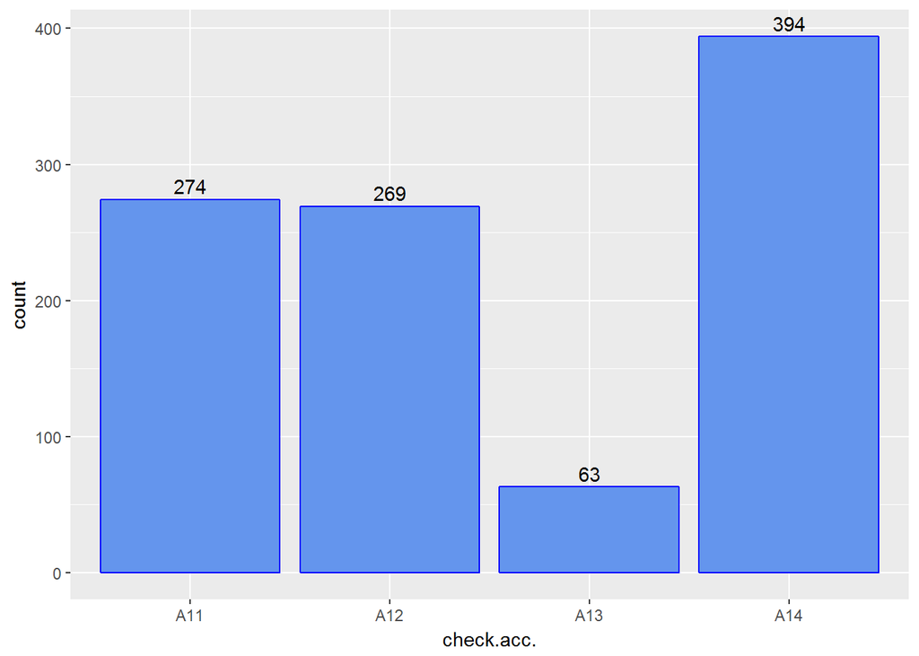

```r
ggplot(my_data,aes(x=check.acc.))+geom_bar(stat = "count",fill= "cornflowerblue",col="blue")+geom_text(stat='count',aes(label = ..count..),vjust = -0.4)
```

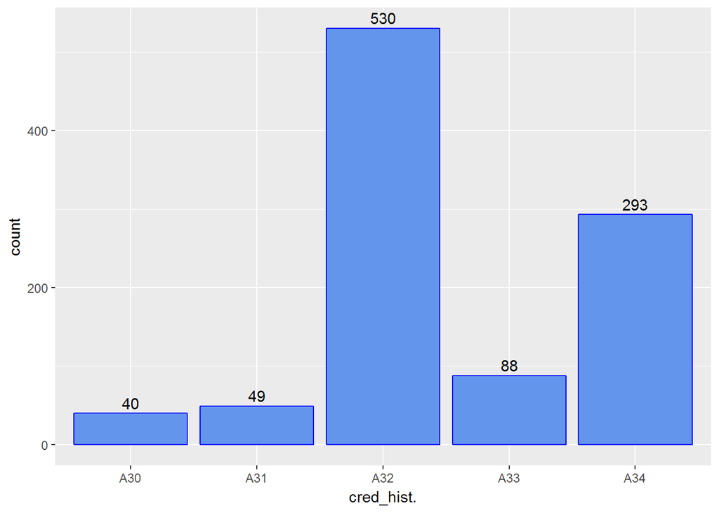

```r
ggplot(my_data,aes(x=cred_hist.))+geom_bar(stat = "count",fill= "cornflowerblue",col="blue")+geom_text(stat='count',aes(label = ..count..),vjust = -0.4)
```

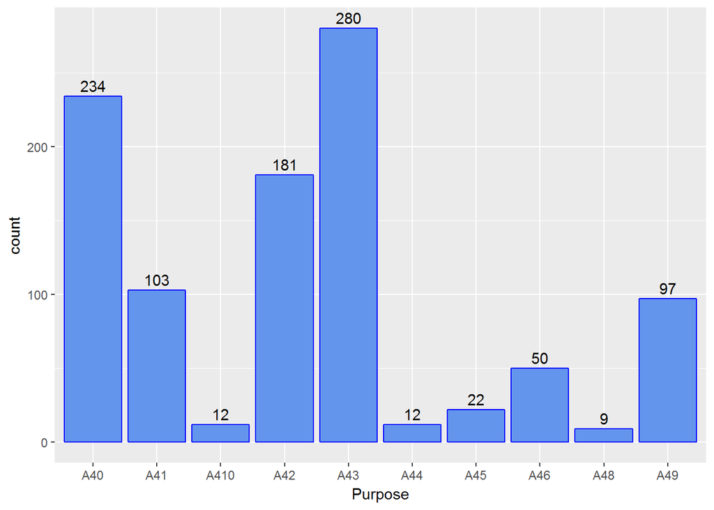

```r
ggplot(my_data,aes(x=Purpose))+geom_bar(stat = "count",fill= "cornflowerblue",col="blue")+geom_text(stat='count',aes(label = ..count..),vjust = -0.4)
```

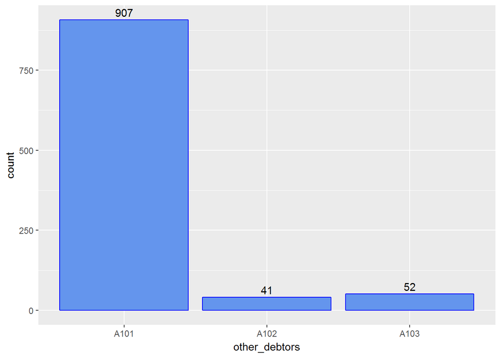

```r
ggplot(my_data,aes(x=other_debtors))+geom_bar(stat = "count",fill= "cornflowerblue",col="blue")+geom_text(stat='count',aes(label = ..count..),vjust = -0.4)
```

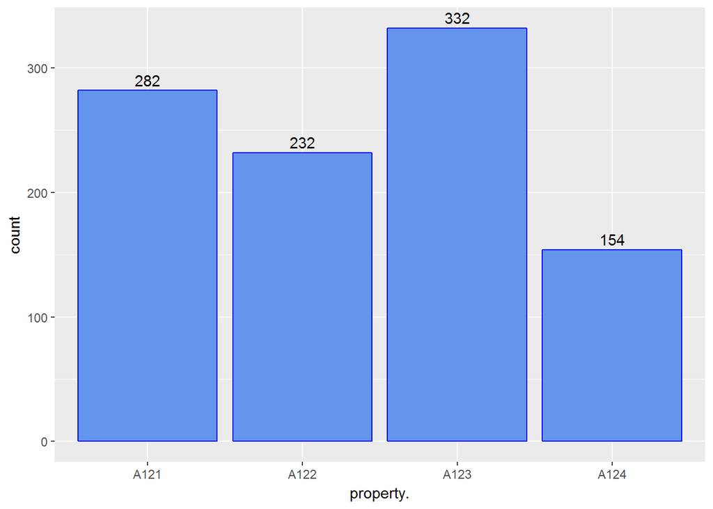

```r
ggplot(my_data,aes(x=property.))+geom_bar(stat = "count",fill= "cornflowerblue",col="blue")+geom_text(stat='count',aes(label = ..count..),vjust = -0.4)
```

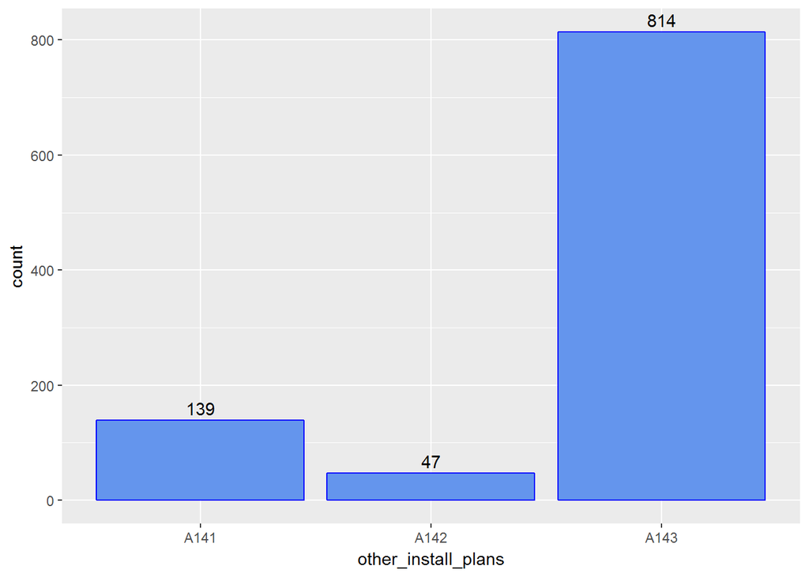

```r
ggplot(my_data,aes(x=other_install_plans))+geom_bar(stat = "count",fill= "cornflowerblue",col="blue")+geom_text(stat='count',aes(label = ..count..),vjust = -0.4)
```

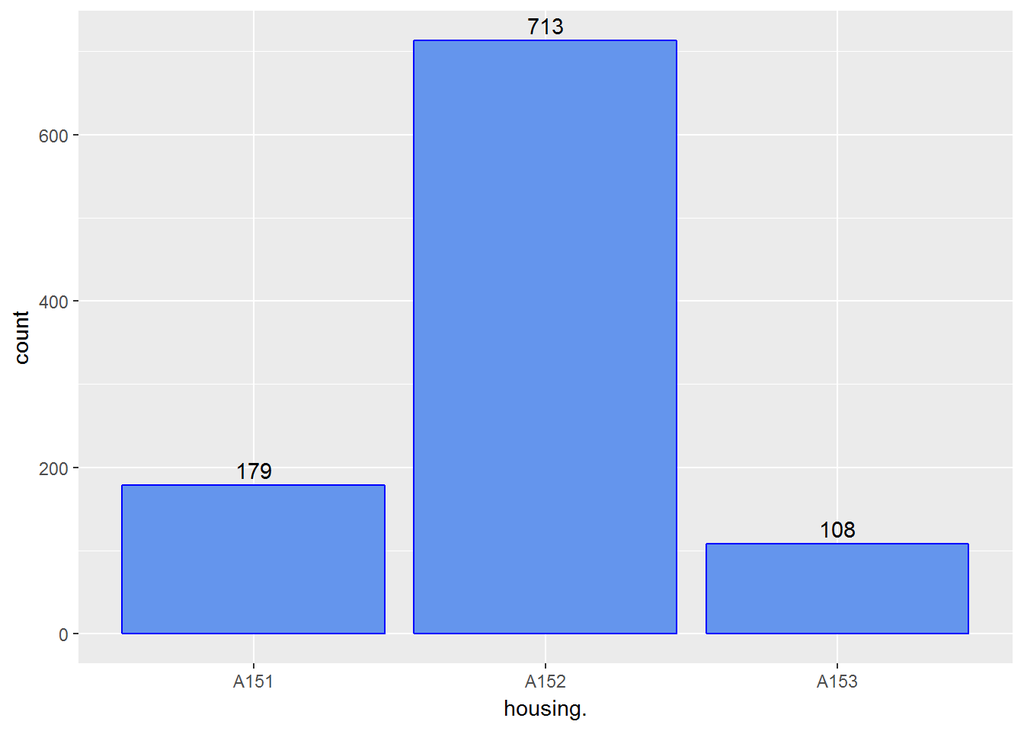

```r
ggplot(my_data,aes(x=housing.))+geom_bar(stat = "count",fill= "cornflowerblue",col="blue")+geom_text(stat='count',aes(label = ..count..),vjust = -0.4)
```

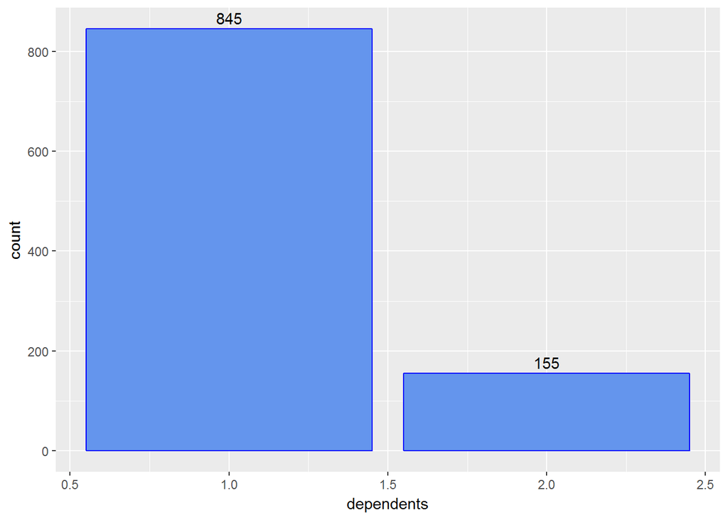

```r
ggplot(my_data,aes(x= dependents))+geom_bar(stat = "count",fill= "cornflowerblue",col="blue")+geom_text(stat='count',aes(label = ..count..),vjust = -0.4)
```

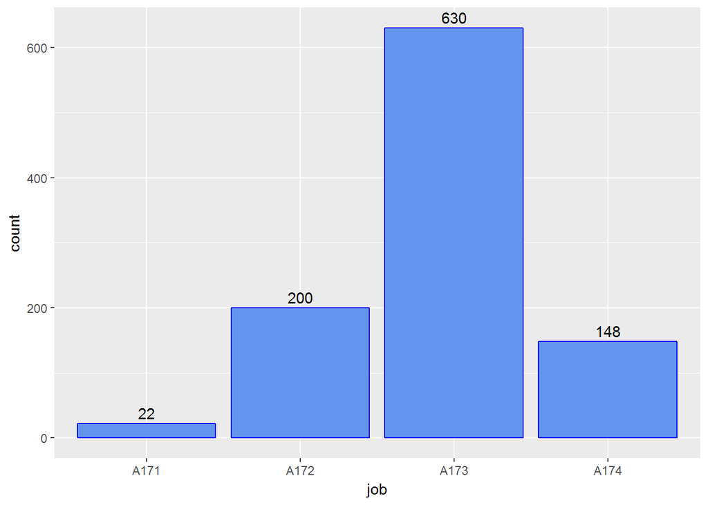

```r
ggplot(my_data,aes(x= job))+geom_bar(stat = "count",fill= "cornflowerblue",col="blue")+geom_text(stat='count',aes(label = ..count..),vjust = -0.4)
```

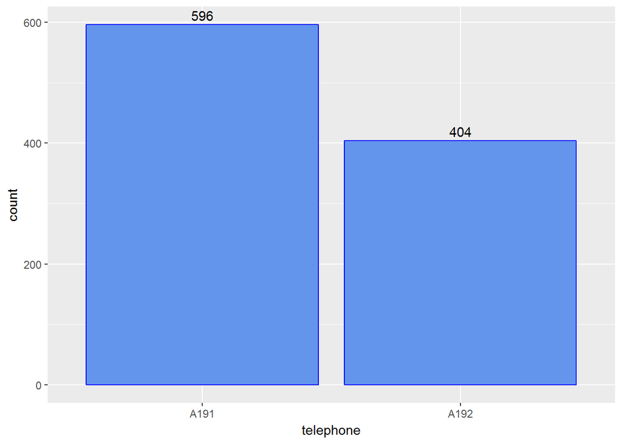

```r
ggplot(my_data,aes(x=telephone))+geom_bar(stat = "count",fill= "cornflowerblue",col="blue")+geom_text(stat='count',aes(label = ..count..),vjust = -0.4)
```

## Target Variable

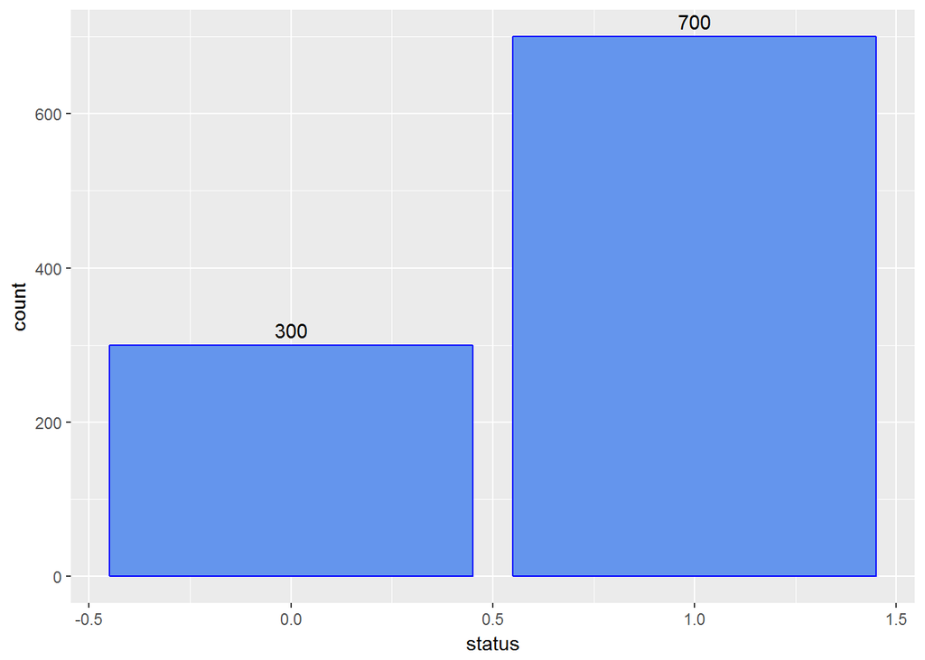

```r
ggplot(my_data,aes(x=status))+geom_bar(stat = "count",fill= "cornflowerblue",col="blue")+geom_text(stat='count',aes(label = ..count..),vjust = -0.5)
```

# Splitting Data (Train - Test - Validation )

## * Splitting the data into (60,20,20)%

```r
set.seed(100)
split_data <- sample(1:3, size=nrow(my_data), prob=c(0.600,0.200,0.200), replace = TRUE)
train <- my_data[split_data==1,]
test <- my_data[split_data==2,]
validation <- my_data[split_data==3,]
```

# TRAIN & TEST DISTRIBUTION

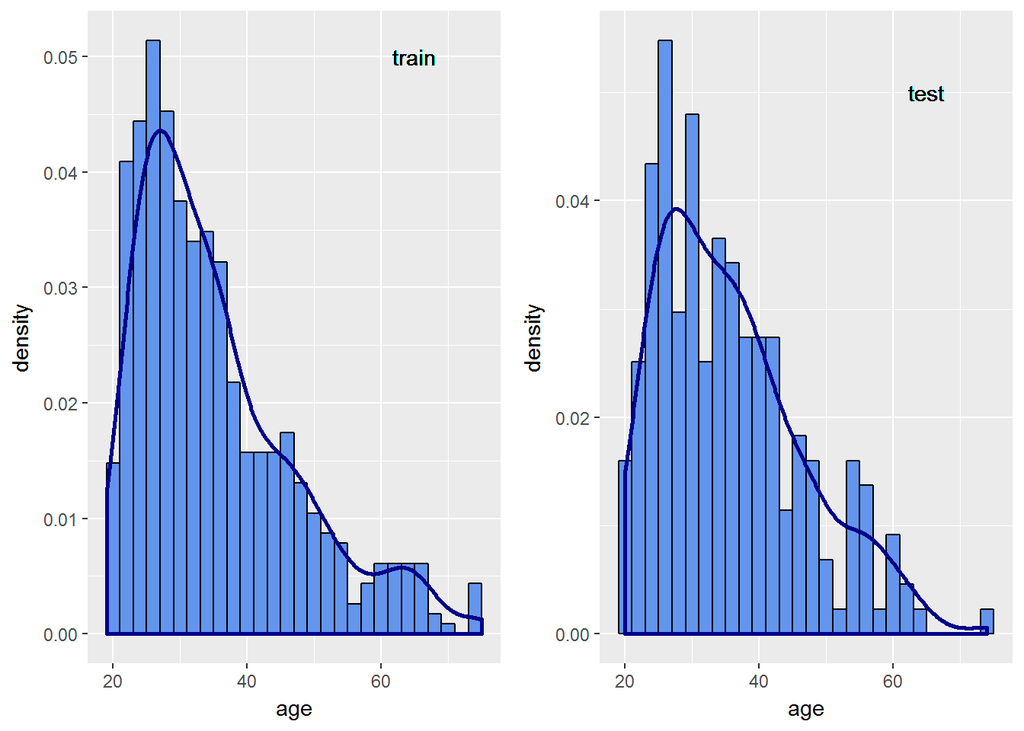

```r
p1 <- ggplot(train, aes(x=age)) +geom_histogram(aes(y=..density..),binwidth = 2, colour = "black",fill= "cornflowerblue")+ geom_density(alpha= 0.5,colour = "blue4", lwd = 1)+geom_text(x=65,y=0.05,label = "train")
p2 <- ggplot(test, aes(x=age)) +geom_histogram(aes(y=..density..),binwidth = 2, colour = "black",fill= "cornflowerblue")+ geom_density(alpha= 0.5,colour = "blue4", lwd = 1)+geom_text(x=65,y=0.05,label = "test")

grid.arrange(p1,p2,nrow= 1)
```

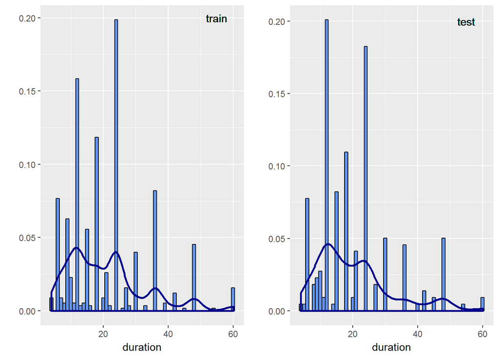

```r
p1 <-ggplot(train, aes(x=duration)) +geom_histogram(aes(y=..density..),binwidth = 1, colour = "black",fill= "cornflowerblue")+ geom_density(alpha= 0.5,colour = "blue4", lwd = 1)+ylab("")+geom_text(x=55,y=0.20,label = "train")
p2 <-ggplot(test, aes(x=duration)) +geom_histogram(aes(y=..density..),binwidth = 1, colour = "black",fill= "cornflowerblue")+ geom_density(alpha= 0.5,colour = "blue4", lwd = 1)+ylab("")+geom_text(x=55,y=0.20,label = "test")

grid.arrange(p1,p2,nrow= 1)
```

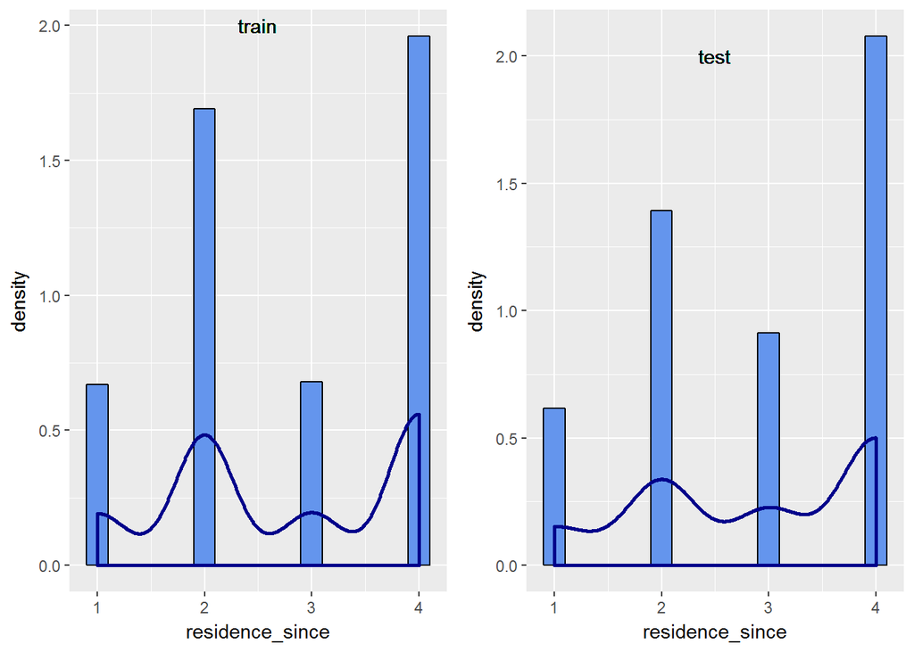

```r
p1 <-ggplot(train, aes(x=residence_since)) +geom_histogram(aes(y=..density..),binwidth = 0.2, colour = "black",fill= "cornflowerblue")+ geom_density(alpha= 0.5,colour = "blue4", lwd = 1)+geom_text(x=65,y=0.05,label = "train")+geom_text(x=2.5,y=2,label = "train")
p2 <-ggplot(test, aes(x=residence_since)) +geom_histogram(aes(y=..density..),binwidth = 0.2, colour = "black",fill= "cornflowerblue")+ geom_density(alpha= 0.5,colour = "blue4", lwd = 1)+geom_text(x=2.5,y=2,label = "test")

grid.arrange(p1,p2,nrow= 1)
```

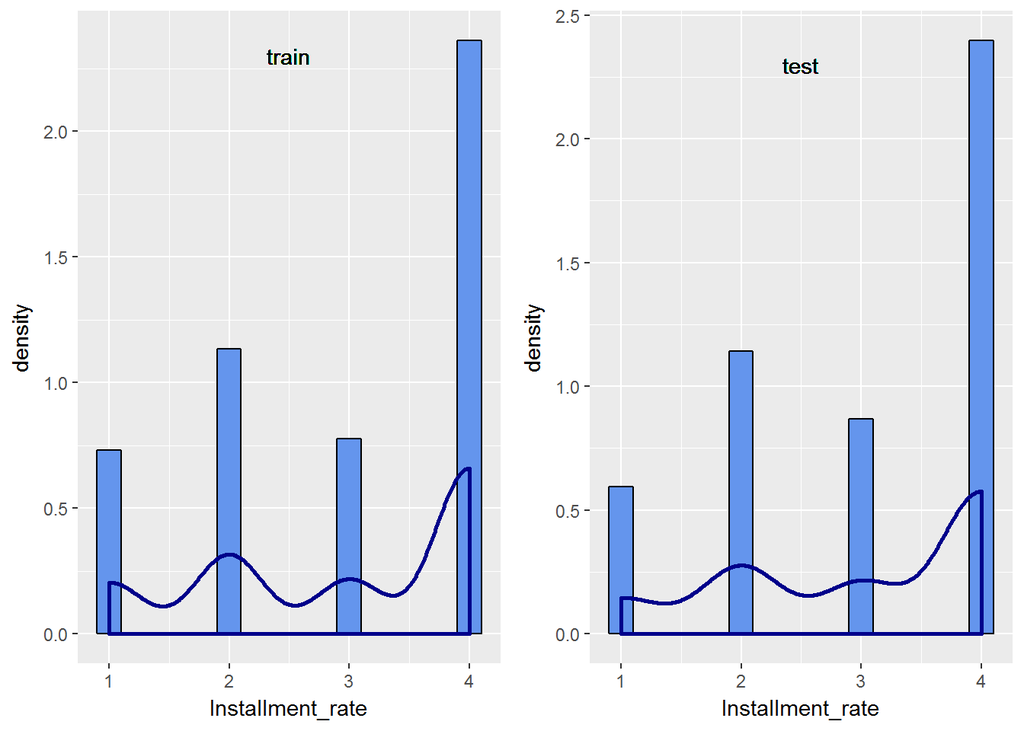

```r
p1 <-ggplot(train, aes(x=Installment_rate)) +geom_histogram(aes(y=..density..),binwidth = 0.2, colour = "black",fill= "cornflowerblue")+ geom_density(alpha= 0.5,colour = "blue4", lwd = 1)+geom_text(x=2.5,y=2.3,label = "train")
p2 <-ggplot(test, aes(x=Installment_rate)) +geom_histogram(aes(y=..density..),binwidth = 0.2, colour = "black",fill= "cornflowerblue")+ geom_density(alpha= 0.5,colour = "blue4", lwd = 1)+geom_text(x=2.5,y=2.3,label = "test")

grid.arrange(p1,p2,nrow= 1)
```

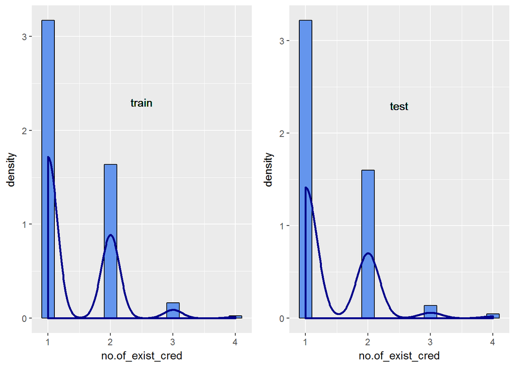

```r
p1 <-ggplot(train, aes(x=no.of_exist_cred)) +geom_histogram(aes(y=..density..),binwidth = 0.2, colour = "black",fill= "cornflowerblue")+ geom_density(alpha= 0.5,colour = "blue4", lwd = 1)+geom_text(x=2.5,y=2.3,label = "train")
p2 <-ggplot(test, aes(x=no.of_exist_cred)) +geom_histogram(aes(y=..density..),binwidth = 0.2, colour = "black",fill= "cornflowerblue")+ geom_density(alpha= 0.5,colour = "blue4", lwd = 1)+geom_text(x=2.5,y=2.3,label = "test")

grid.arrange(p1,p2,nrow= 1)
```

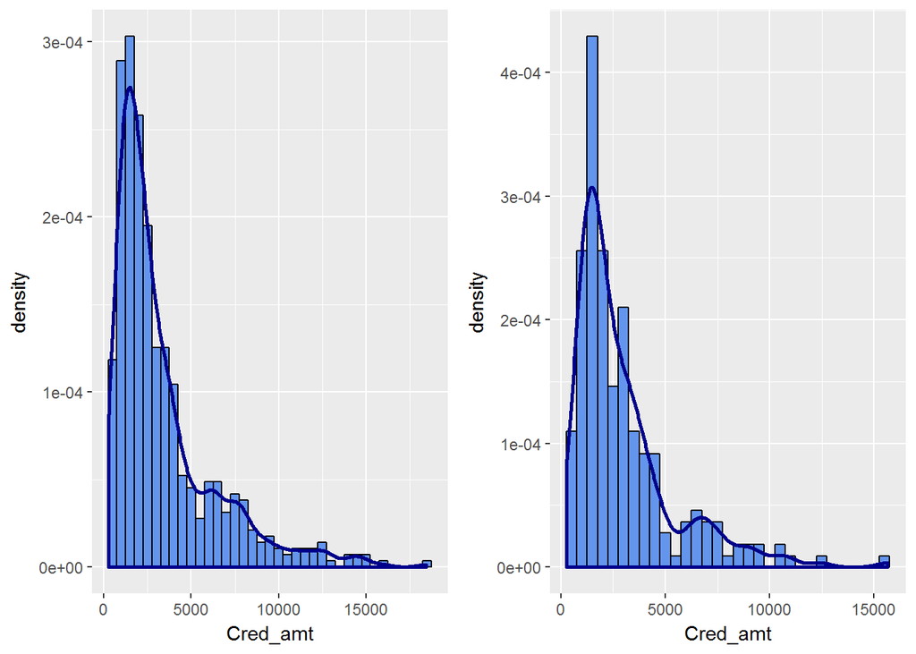

```r
p1 <-ggplot(train, aes(x=Cred_amt)) +geom_histogram(aes(y=..density..),binwidth = 500, colour = "black",fill= "cornflowerblue")+ geom_density(alpha= 0.5,colour = "blue4", lwd = 1)+geom_text(x=2.5,y=2.3,label = "train")
p2 <-ggplot(test, aes(x=Cred_amt)) +geom_histogram(aes(y=..density..),binwidth = 500, colour = "black",fill= "cornflowerblue")+ geom_density(alpha= 0.5,colour = "blue4", lwd = 1)+geom_text(x=2.5,y=2.3,label = "test")

grid.arrange(p1,p2,nrow= 1)
```

- ** The above plots shows that the test and train data belongs have same type of distribution**

# UNIVARIATE ANALYSIS

## * QQ plot

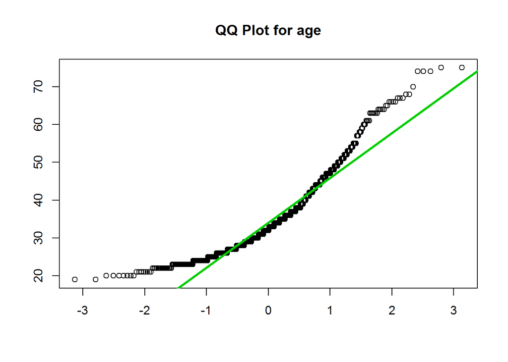

```r
qqnorm(train$age,main = "QQ Plot for age",xlab = "",ylab = "")
qqline(train$age,col = 3,lwd = 3)
```

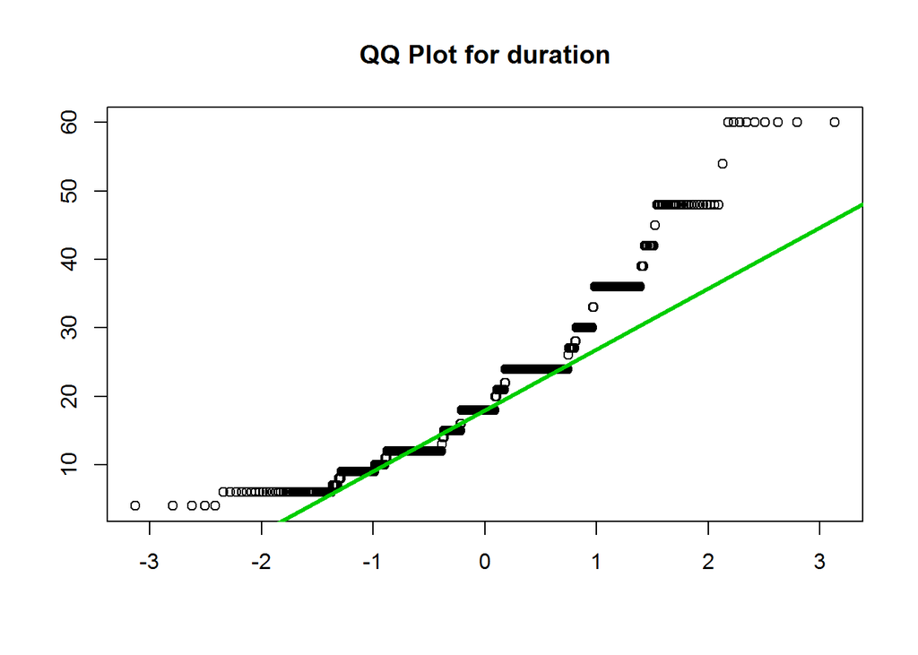

```r
qqnorm(train$duration,main = "QQ Plot for duration",xlab = "",ylab = "")
qqline(train$duration,col = 3,lwd = 3)
```

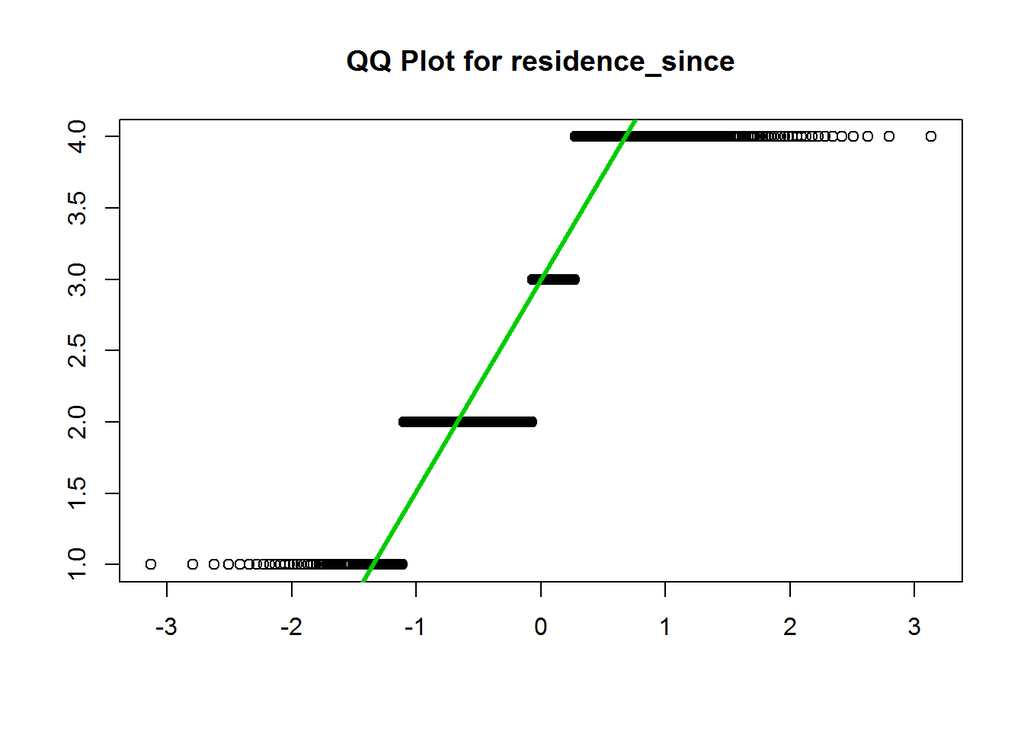

```r
qqnorm(train$residence_since,main = "QQ Plot for residence_since",xlab = "",ylab = "")
qqline(train$residence_since,col = 3,lwd = 3)
```

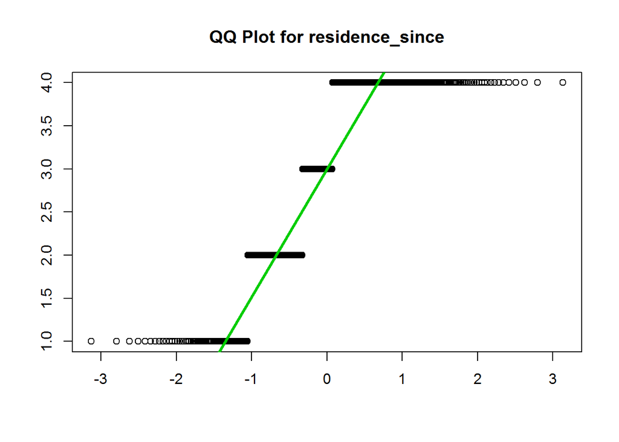

```r
qqnorm(train$Installment_rate,main = "QQ Plot for residence_since",xlab = "",ylab = "")
qqline(train$Installment_rate,col = 3,lwd = 3)
```

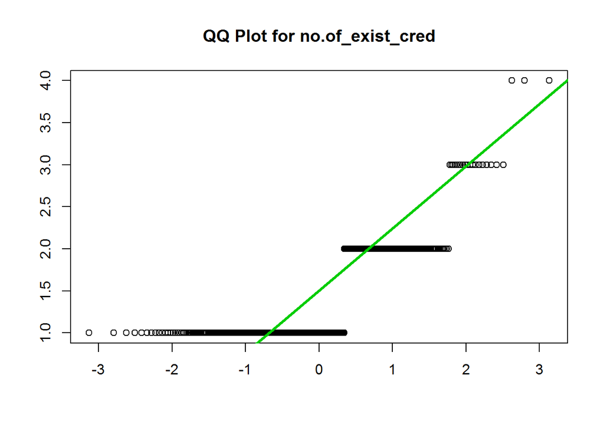

```r
qqnorm(train$no.of_exist_cred,main = "QQ Plot for no.of_exist_cred",xlab = "",ylab = "")
qqline(train$no.of_exist_cred,col = 3,lwd = 3)
```

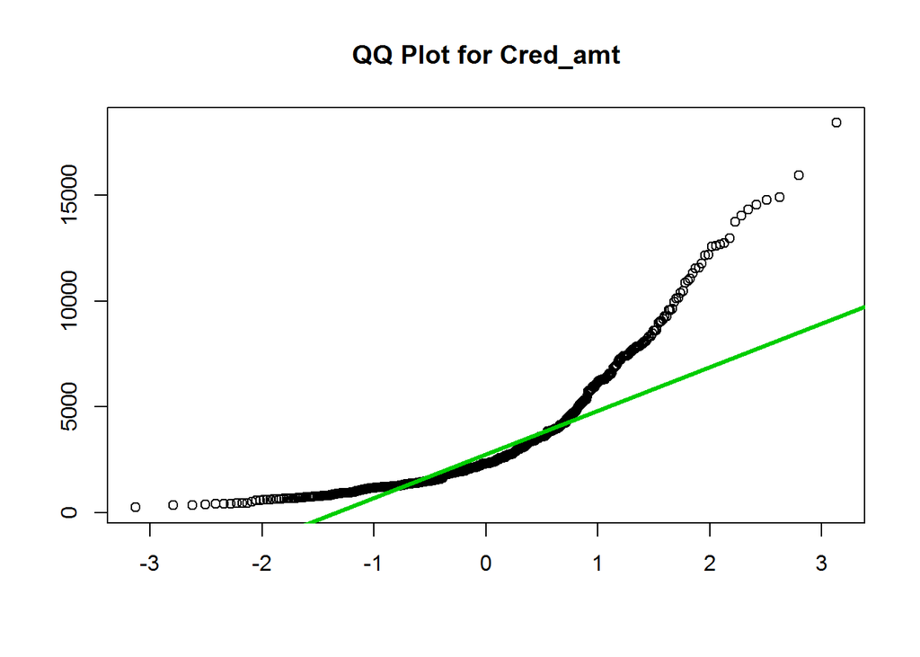

```r
qqnorm(train$Cred_amt,main = "QQ Plot for Cred_amt",xlab = "",ylab = "")
qqline(train$Cred_amt,col = 3,lwd = 3)
```

These qq plots helps us to compare our distribution with normal distribution

# OUTLIER TREATMENT

## * Box Plot

- Boxplot helps us to analyse the skewness in our dataset and also to detect the outliers.
- It is one of the way to display the distribution of data based on the five number summary.

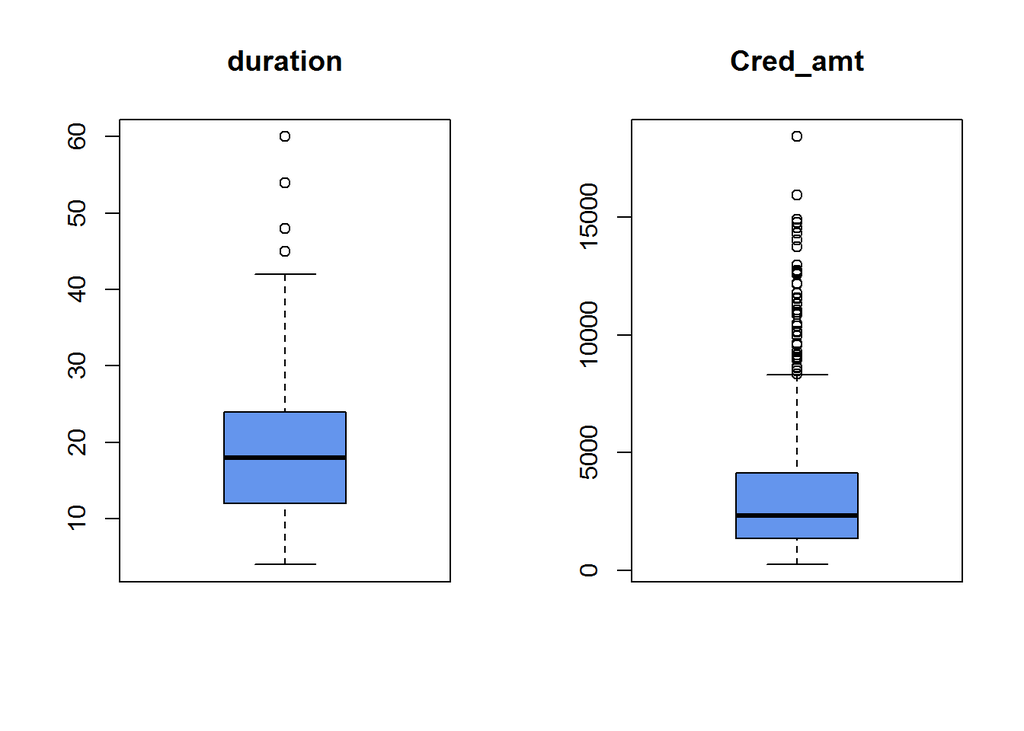

```r
par(mfrow=c(1,2))
boxplot(train$duration,col ="cornflowerblue",main="duration")
boxplot(train$Cred_amt,col ="cornflowerblue",main="Cred_amt")
```

*Stats for the outliers

```r
boxplot.stats(train$duration)
```

```
## $stats
## [1]  4 12 18 24 42
##
## $n
## [1] 574
##
## $conf
## [1] 17.20862 18.79138
##
## $out
##  [1] 48 60 48 54 48 48 60 48 48 48 48 48 48 48 48 60 48 60 60 48 48 48 48
## [24] 48 60 48 48 60 48 60 48 48 48 48 48 60 45
```

```r
table(boxplot.stats(train$duration)$out)
```

```
##
## 45 48 54 60
##  1 26  1  9
```

```r
boxplot.stats(train$Cred_amt)
```

```
## $stats
## [1]  250 1366 2324 4153 8318
##
## $n
## [1] 574
##
## $conf
## [1] 2140.203 2507.797
##
## $out
##  [1]  9055 12579  9566 12612 15945  8487 10144  8613  9572 10961 14555
## [12] 12169  9960 10127 11590 13756 14782 14318 12976 11760  8648 11328
## [23] 11054  9034  8588 12204  9157 10366 14027 11560 12680  9271  9283
## [34]  9629  8335 10875  8947 10477 18424 14896 12749
```

```r
table(boxplot.stats(train$Cred_amt)$out)
```

```
##
##  8335  8487  8588  8613  8648  8947  9034  9055  9157  9271  9283  9566
##     1     1     1     1     1     1     1     1     1     1     1     1
##  9572  9629  9960 10127 10144 10366 10477 10875 10961 11054 11328 11560
##     1     1     1     1     1     1     1     1     1     1     1     1
## 11590 11760 12169 12204 12579 12612 12680 12749 12976 13756 14027 14318
##     1     1     1     1     1     1     1     1     1     1     1     1
## 14555 14782 14896 15945 18424
##     1     1     1     1     1
```

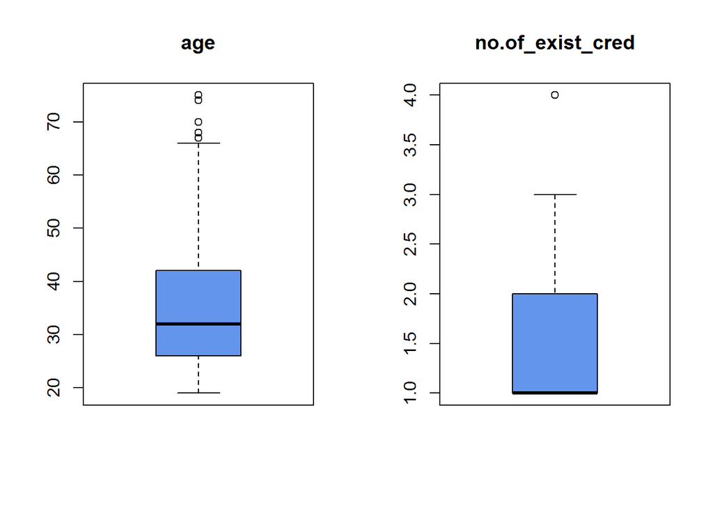

```r
par(mfrow=c(1,2))
boxplot(train$age,col ="cornflowerblue",main="age")
boxplot(train$no.of_exist_cred,col ="cornflowerblue",main="no.of_exist_cred")
```

*Stats for the outliers

```r
boxplot.stats(train$age)
```

```
## $stats
## [1] 19 26 32 42 66
##
## $n
## [1] 574
##
## $conf
## [1] 30.94483 33.05517
##
## $out
##  [1] 67 70 74 68 75 75 67 74 74 67 68
```

```r
table(boxplot.stats(train$age)$out)
```

```
##
## 67 68 70 74 75
##  3  2  1  3  2
```

```r
boxplot.stats(train$no.of_exist_cred)
```

```
## $stats
## [1] 1 1 1 2 3
##
## $n
## [1] 574
##
## $conf
## [1] 0.9340521 1.0659479
##
## $out
## [1] 4 4 4
```

```r
table(boxplot.stats(train$no.of_exist_cred)$out)
```

```
##
## 4
## 3
```

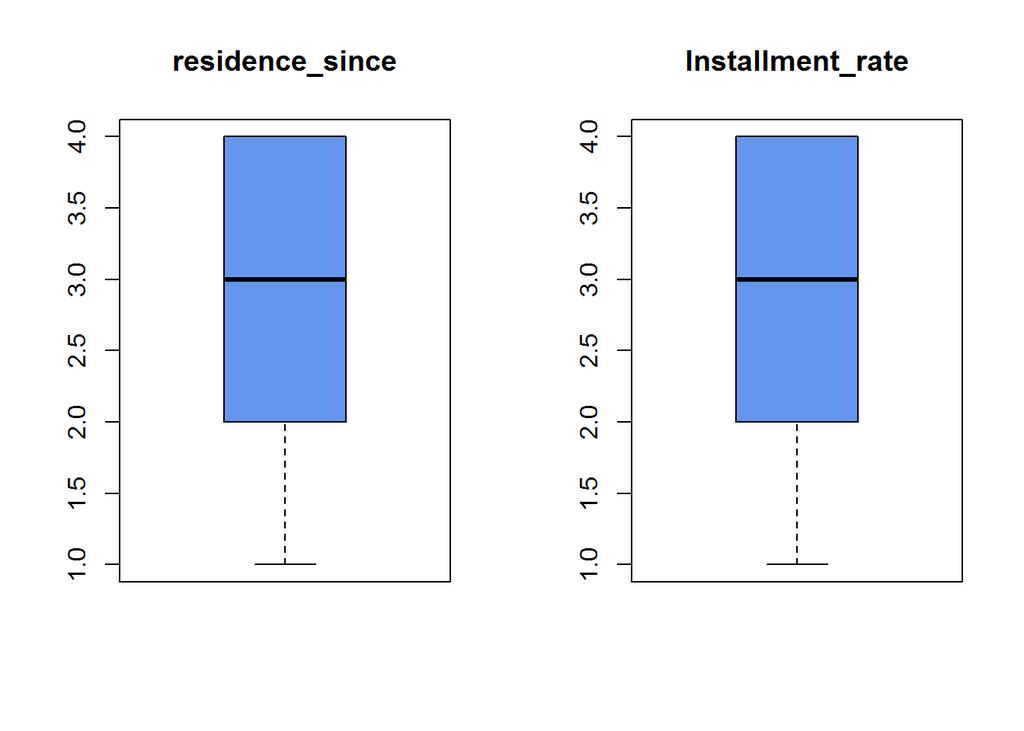

```r
par(mfrow=c(1,2))
boxplot(train$residence_since,col ="cornflowerblue",main="residence_since")
boxplot(train$Installment_rate,col ="cornflowerblue",main="Installment_rate")
```

*Stats for the outliers

```r
boxplot.stats(train$residence_since)
```

```
## $stats
## [1] 1 2 3 4 4
##
## $n
## [1] 574
##
## $conf
## [1] 2.868104 3.131896
##
## $out
## integer(0)
```

```r
table(boxplot.stats(train$residence_since)$out)
```

```
## < table of extent 0 >
```

```r
boxplot.stats(train$Installment_rate)
```

```
## $stats
## [1] 1 2 3 4 4
##
## $n
## [1] 574
##
## $conf
## [1] 2.868104 3.131896
##
## $out
## integer(0)
```

```r
table(boxplot.stats(train$Installment_rate)$out)
```

```
## < table of extent 0 >
```

- This shows that Age, Cred_amt and duration attributes needs to be treated.

# Statistical Information

```r
col <- cbind(train$duration, train$Cred_amt, train$Installment_rate ,train$residence_since, train$age, train$no.of_exist_cred,train$dependents,train$status)
stat.desc(col, basic = FALSE)
```

|  | V1 | V2 | V3 | V4 | V5 | V6 | V7 | V8 |
| --- | --- | --- | --- | --- | --- | --- | --- | --- |
| median | 18.0000000 | 2.324000e+03 | 3.00000000 | 3.00000000 | 32.0000000 | 1.00000000 | 1.00000000 | 1.00000000 |
| mean | 20.8919861 | 3.372141e+03 | 2.95296167 | 2.78571429 | 35.4634146 | 1.40940767 | 1.14111498 | 0.68641115 |
| SE.mean | 0.4990560 | 1.230485e+02 | 0.04729617 | 0.04615461 | 0.4956308 | 0.02433600 | 0.01454376 | 0.01938185 |
| CI.mean.0.95 | 0.9802022 | 2.416811e+02 | 0.09289501 | 0.09065286 | 0.9734747 | 0.04779864 | 0.02856559 | 0.03806813 |
| var | 142.9586442 | 8.690892e+06 | 1.28399645 | 1.22276240 | 141.0030222 | 0.33994625 | 0.12141307 | 0.21562654 |
| std.dev | 11.9565314 | 2.948032e+03 | 1.13313567 | 1.10578588 | 11.8744693 | 0.58304909 | 0.34844378 | 0.46435605 |
| coef.var | 0.5723023 | 8.742315e-01 | 0.38372854 | 0.39694878 | 0.3348372 | 0.41368378 | 0.30535378 | 0.67649840 |

# EDA_Bivariate Analysis

## 1. Feature vs Target Variable(Categorical Features)

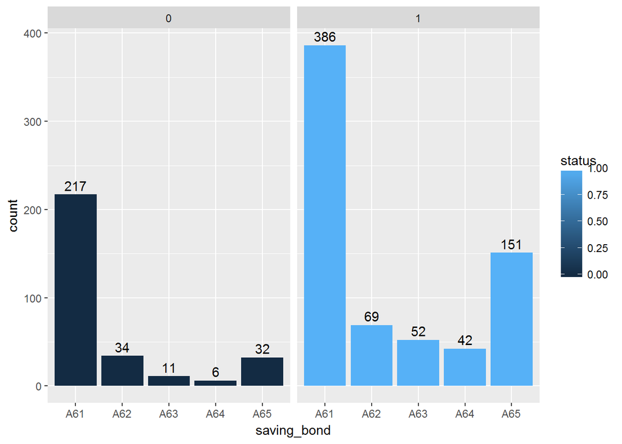

```r
par(mfrow=c(1,4))
ggplot(my_data,aes(x=saving_bond,fill= status))+geom_bar(stat = "count",position = "dodge")+facet_grid(~status)+geom_text(stat='count',aes(label = ..count..),vjust = -0.4)
```

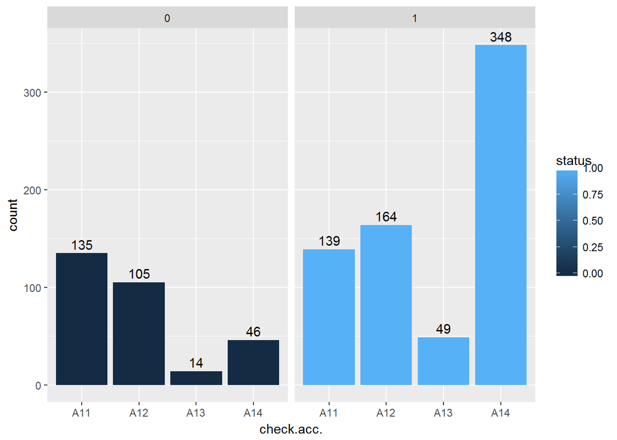

```r
ggplot(my_data,aes(x=check.acc.,fill= status))+geom_bar(stat = "count",position = "dodge")+facet_grid(~status)+geom_text(stat='count',aes(label = ..count..),vjust = -0.4)
```

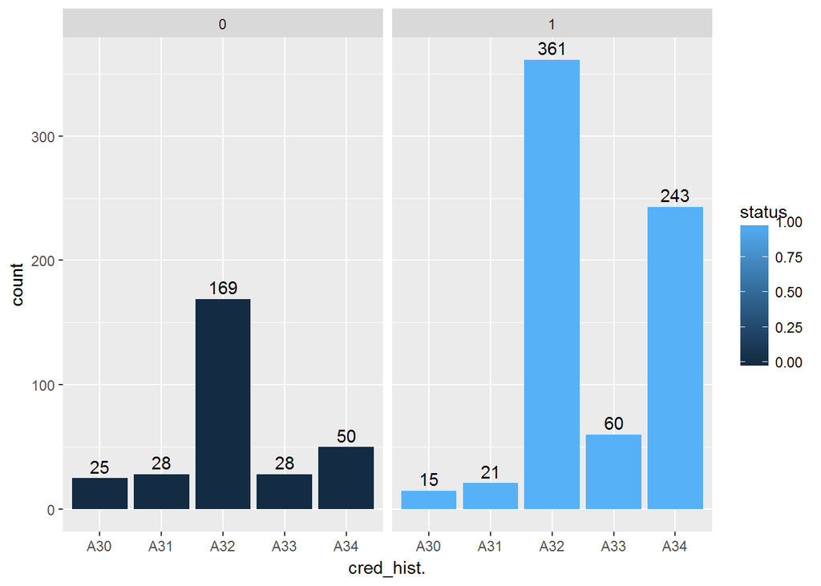

```r
ggplot(my_data,aes(x=cred_hist.,fill= status))+geom_bar(stat = "count",position = "dodge")+facet_grid(~status)+geom_text(stat='count',aes(label = ..count..),vjust = -0.4)
```

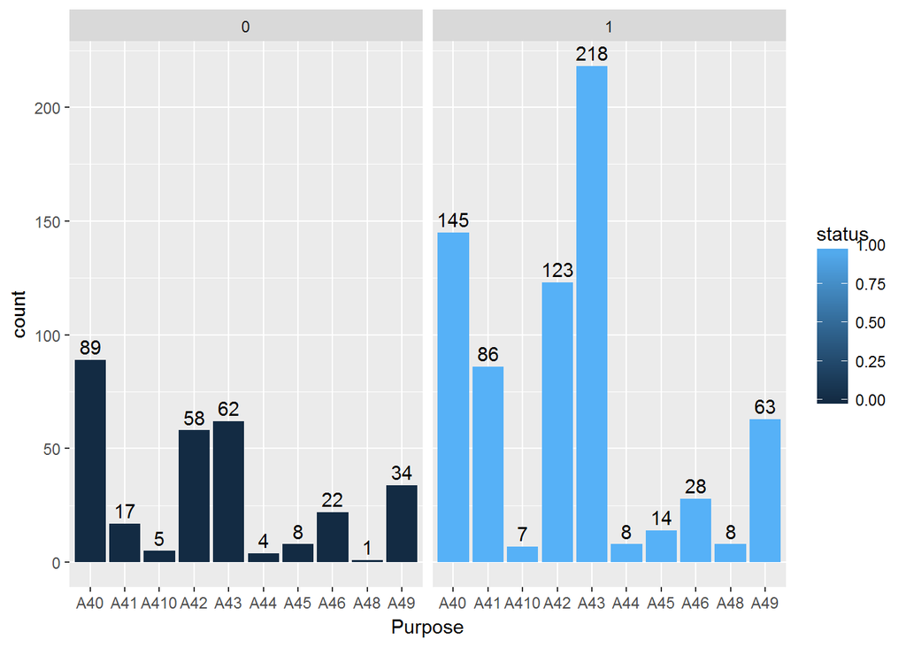

```r
ggplot(my_data,aes(x= Purpose,fill= status))+geom_bar(stat = "count",position = "dodge")+facet_grid(~status)+geom_text(stat='count',aes(label = ..count..),vjust = -0.4)
```

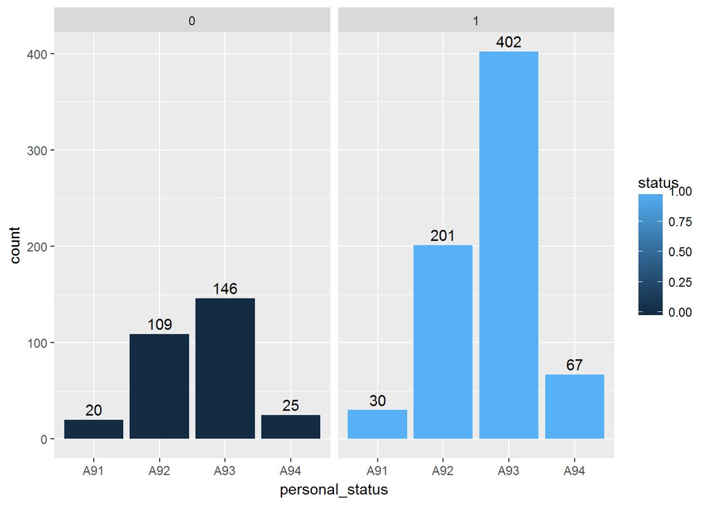

```r
ggplot(my_data,aes(x=personal_status,fill= status))+geom_bar(stat = "count",position = "dodge")+facet_grid(~status)+geom_text(stat='count',aes(label = ..count..),vjust = -0.4)
```

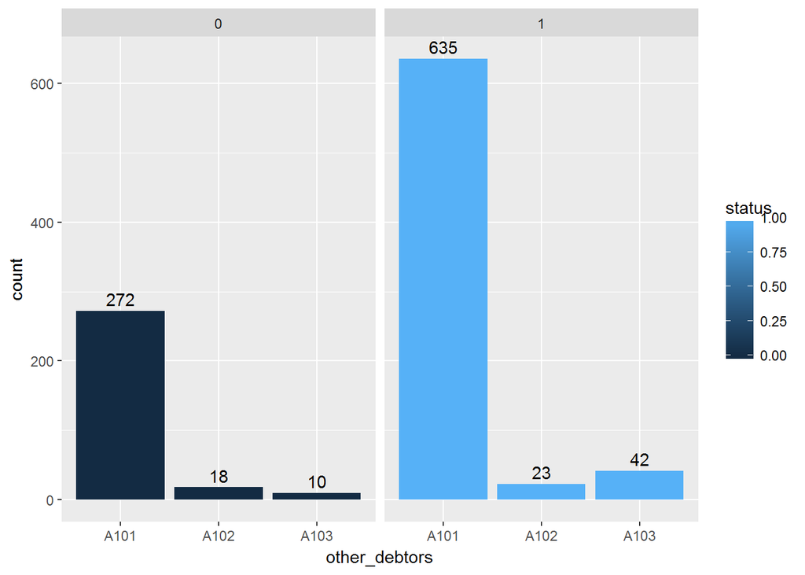

```r
ggplot(my_data,aes(x=other_debtors,fill= status))+geom_bar(stat = "count",position = "dodge")+facet_grid(~status)+geom_text(stat='count',aes(label = ..count..),vjust = -0.4)
```

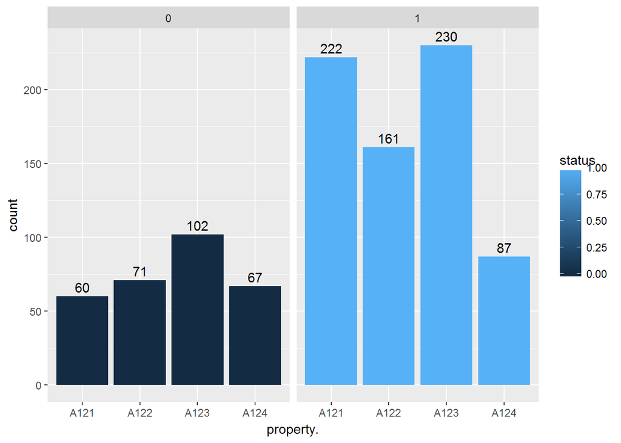

```r
ggplot(my_data,aes(x=property.,fill= status))+geom_bar(stat = "count",position = "dodge")+facet_grid(~status)+geom_text(stat='count',aes(label = ..count..),vjust = -0.4)
```

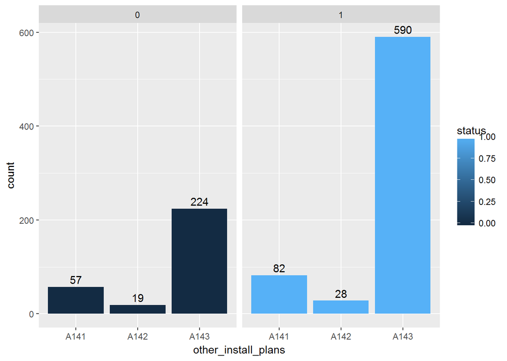

```r
ggplot(my_data,aes(x=other_install_plans,fill= status))+geom_bar(stat = "count",position = "dodge")+facet_grid(~status)+geom_text(stat='count',aes(label = ..count..),vjust = -0.4)
```

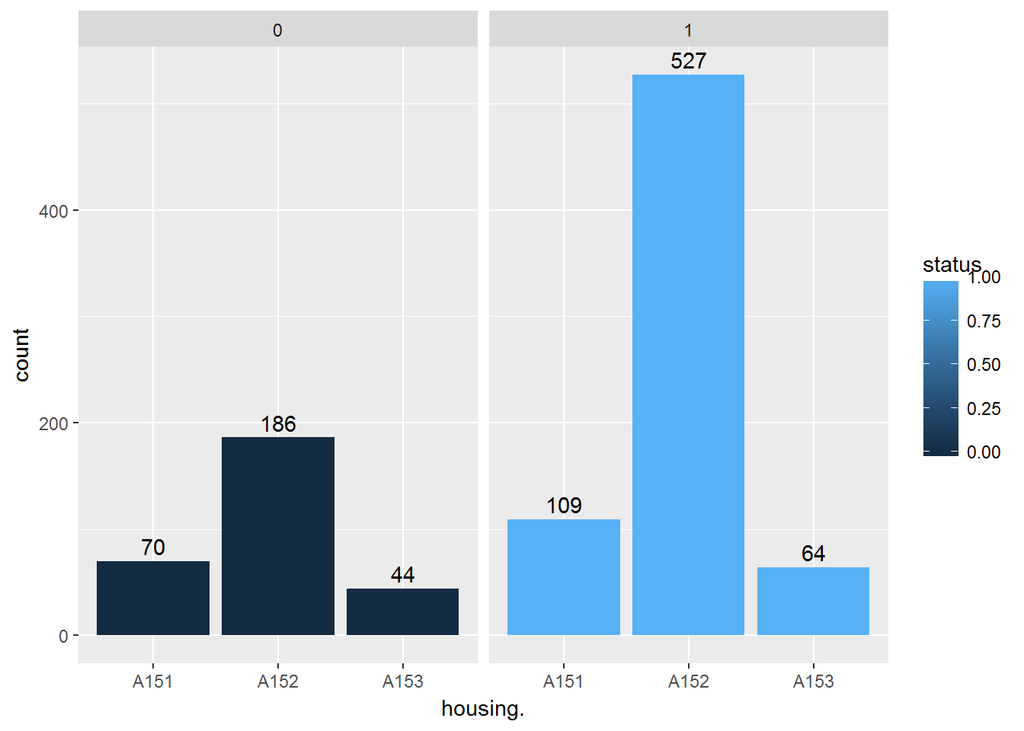

```r
ggplot(my_data,aes(x=housing.,fill= status))+geom_bar(stat = "count",position = "dodge")+facet_grid(~status)+geom_text(stat='count',aes(label = ..count..),vjust = -0.4)
```

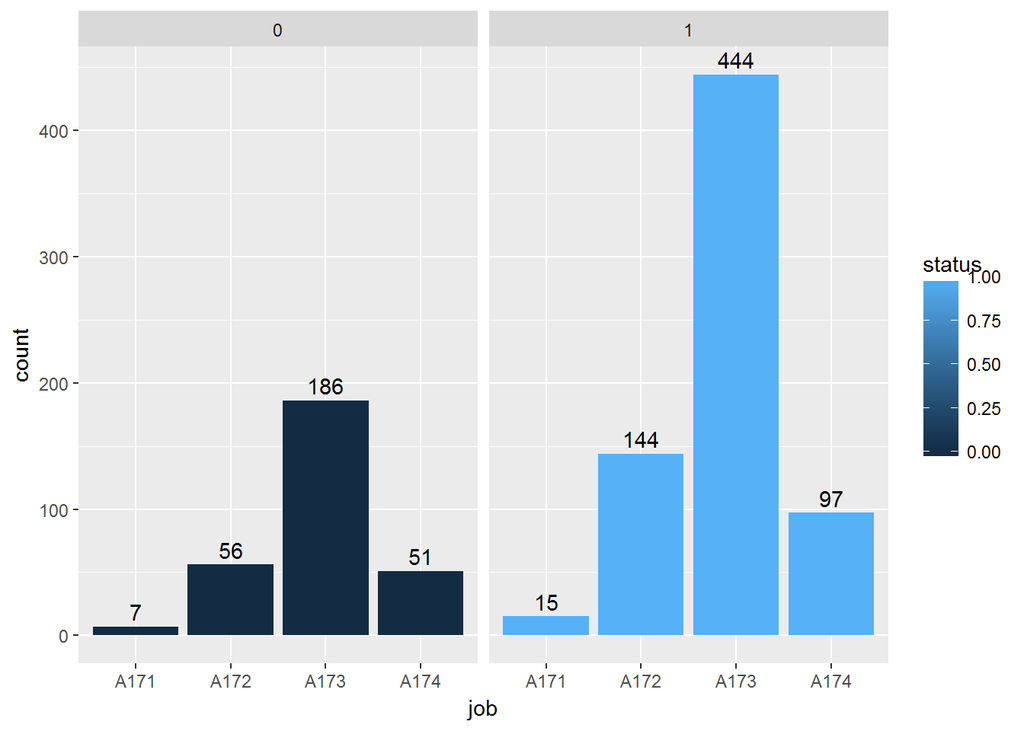

```r
ggplot(my_data,aes(x=job,fill= status))+geom_bar(stat = "count",position = "dodge")+facet_grid(~status)+geom_text(stat='count',aes(label = ..count..),vjust = -0.4)
```

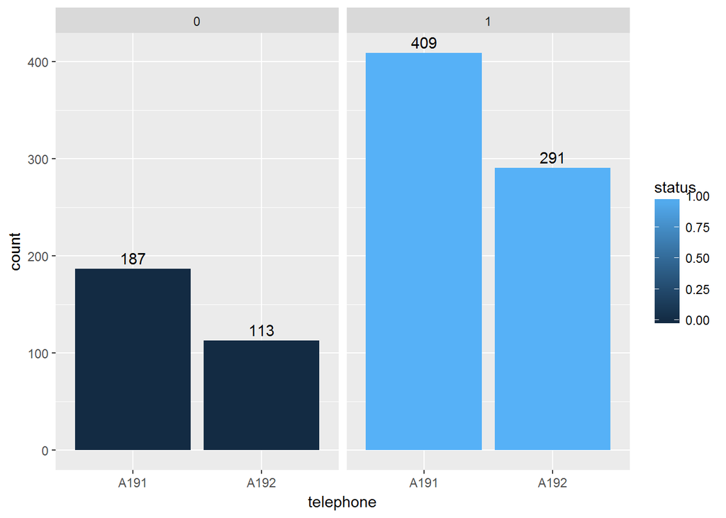

```r
ggplot(my_data,aes(x=telephone,fill= status))+geom_bar(stat = "count",position = "dodge")+facet_grid(~status)+geom_text(stat='count',aes(label = ..count..),vjust = -0.4)
```

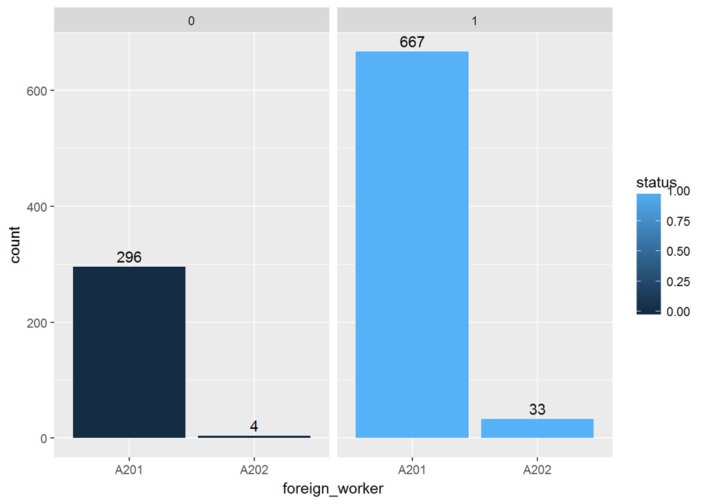

```r
ggplot(my_data,aes(x=foreign_worker,fill= status))+geom_bar(stat = "count",position = "dodge")+facet_grid(~status)+geom_text(stat='count',aes(label = ..count..),vjust = -0.4)
```

## 2. Feature vs Target Variable(Numerical Features)

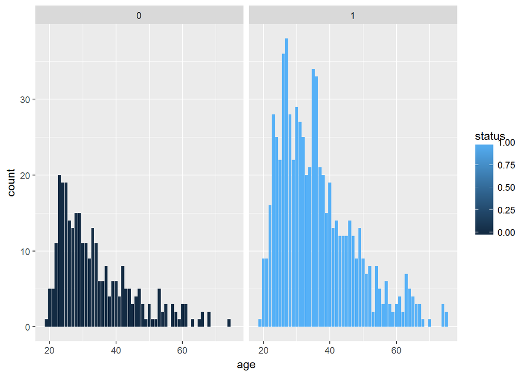

```r
par(mfrow=c(1,2))
ggplot(my_data,aes(x=age,fill= status))+geom_bar(stat = "count",position = "dodge")+facet_grid(~status)
```

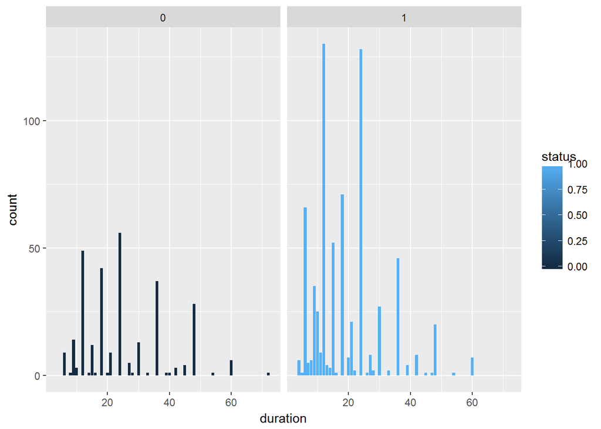

```r
ggplot(my_data,aes(x=duration,fill= status))+geom_bar(stat = "count",position = "dodge")+facet_grid(~status)
```

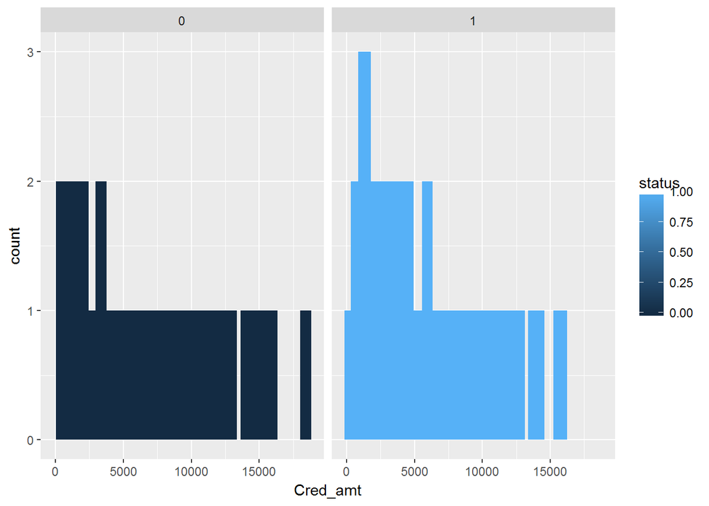

```r
ggplot(my_data,aes(x=Cred_amt,fill= status))+geom_bar(stat = "count",position = "dodge",width = 800)+facet_grid(~status)
```

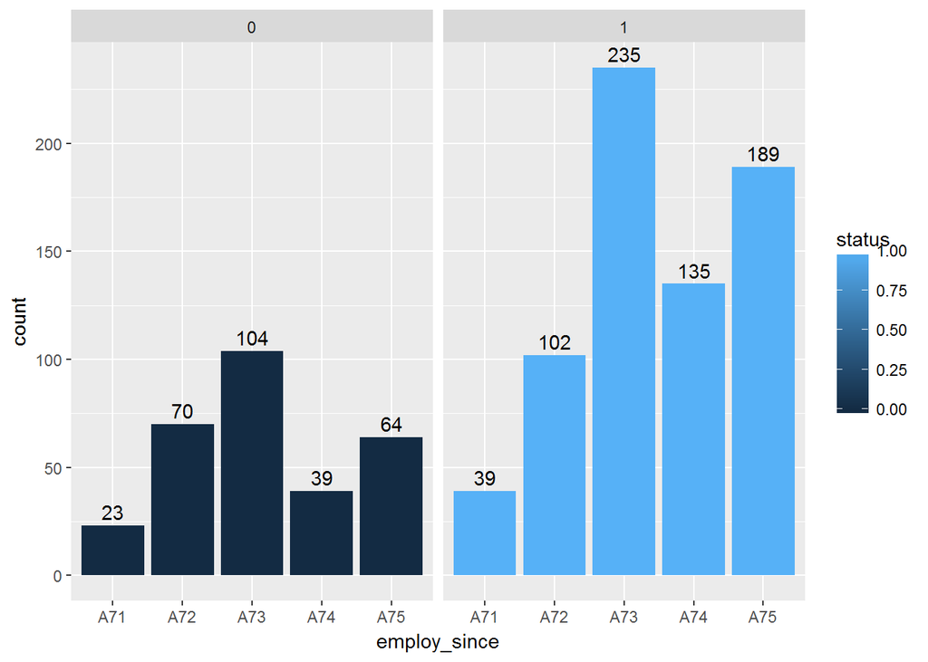

```r
ggplot(my_data,aes(x=employ_since,fill= status))+geom_bar(stat = "count",position = "dodge")+facet_grid(~status)+geom_text(stat='count',aes(label = ..count..),vjust = -0.4)
```

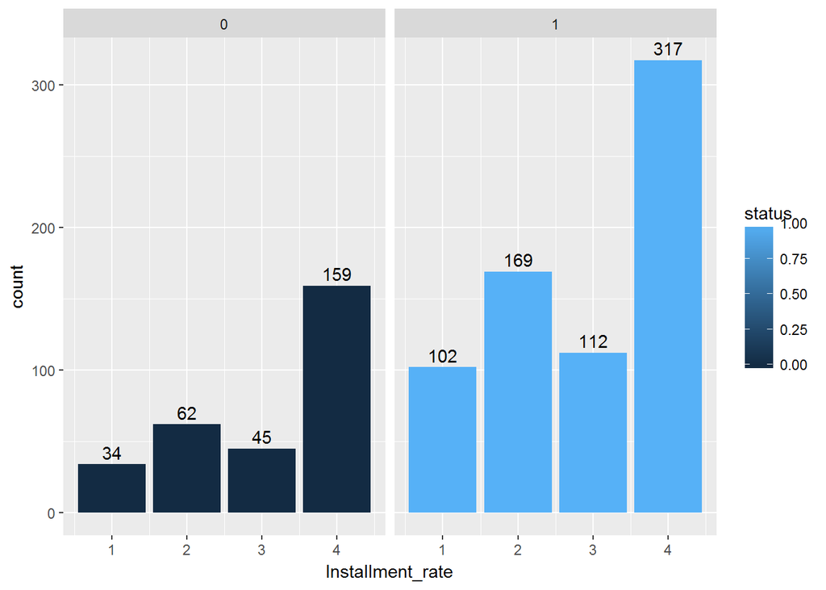

```r
ggplot(my_data,aes(x=Installment_rate,fill= status))+geom_bar(stat = "count",position = "dodge")+facet_grid(~status)+geom_text(stat='count',aes(label = ..count..),vjust = -0.4)
```

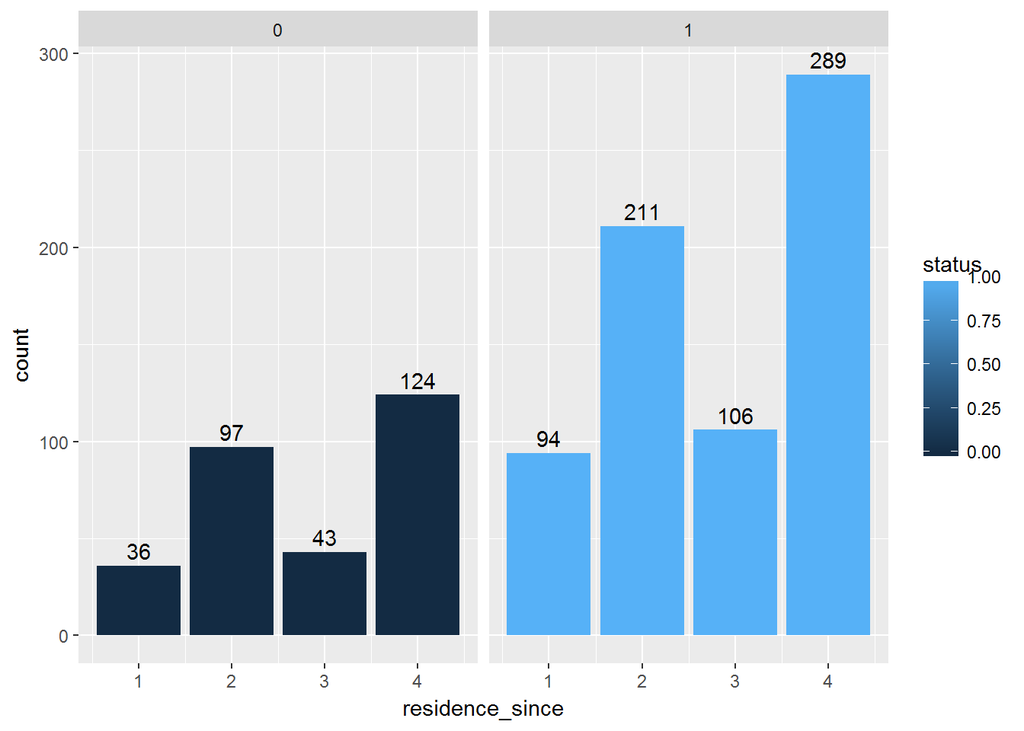

```r
ggplot(my_data,aes(x=residence_since,fill= status))+geom_bar(stat = "count",position = "dodge")+facet_grid(~status)+geom_text(stat='count',aes(label = ..count..),vjust = -0.4)
```

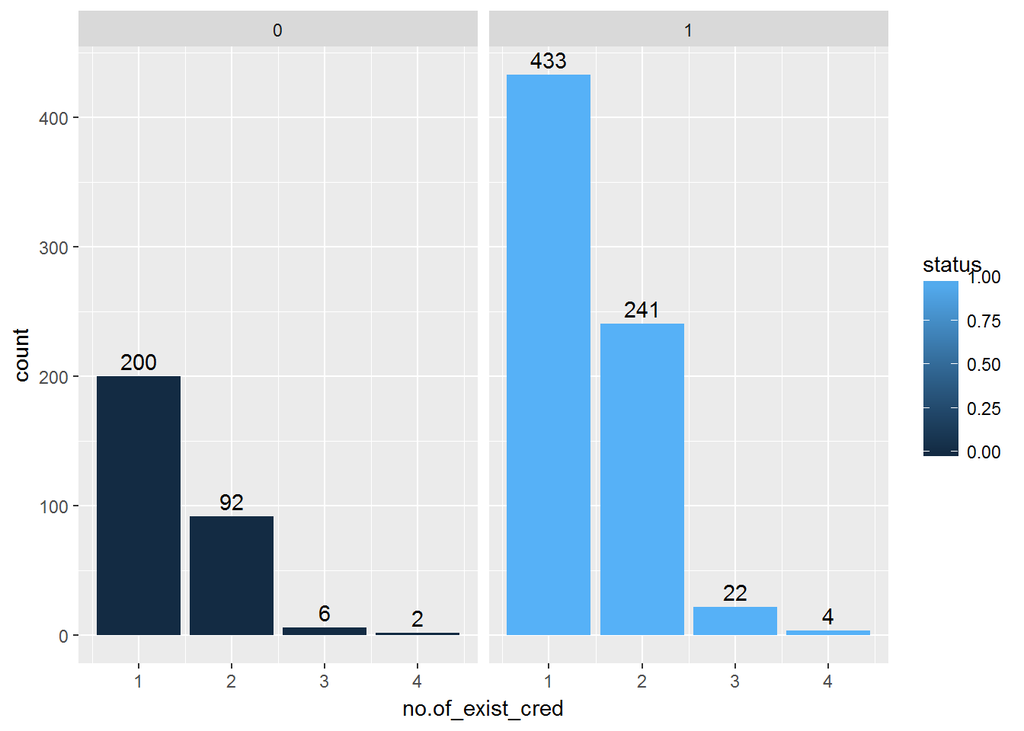

```r
ggplot(my_data,aes(x=no.of_exist_cred,fill= status))+geom_bar(stat = "count",position = "dodge")+facet_grid(~status)+geom_text(stat='count',aes(label = ..count..),vjust = -0.4)
```

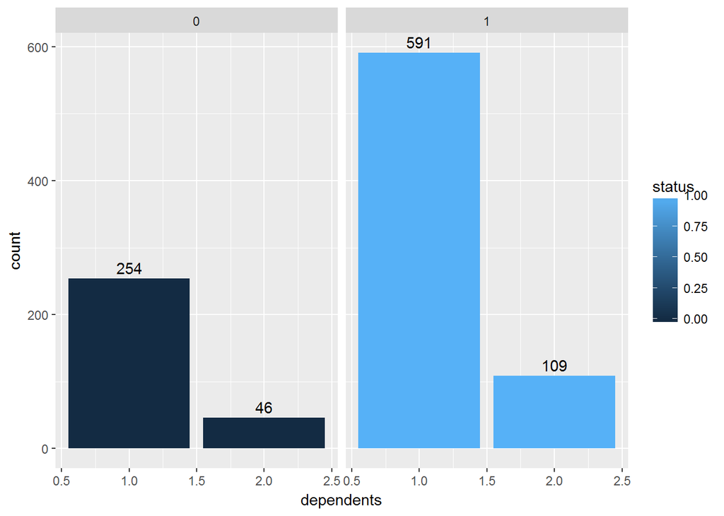

```r
ggplot(my_data,aes(x=dependents,fill= status))+geom_bar(stat = "count",position = "dodge")+facet_grid(~status)+geom_text(stat='count',aes(label = ..count..),vjust = -0.4)
```

# Feature Processing

## 1. Logarithmic Tranformation

```r
train$age <- log(train$age)
train$Cred_amt <- log(train$Cred_amt)
train$duration <- log(train$duration)
```

Now lets see it’s effect:

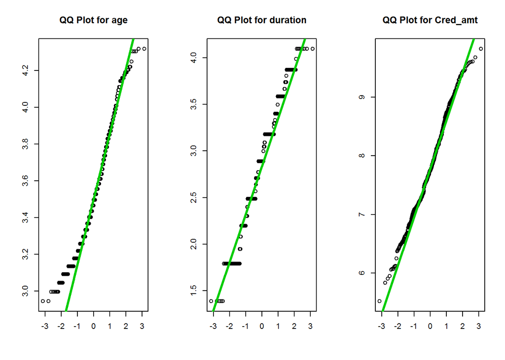

```r
par(mfrow=c(1,3))
qqnorm(train$age,main = "QQ Plot for age",xlab = "",ylab = "")
 qqline(train$age,col = 3,lwd = 3)

 qqnorm(train$duration,main = "QQ Plot for duration",xlab = "",ylab = "")
qqline(train$duration,col = 3,lwd = 3)

qqnorm(train$Cred_amt,main = "QQ Plot for Cred_amt",xlab = "",ylab = "")
qqline(train$Cred_amt,col = 3,lwd = 3)
```

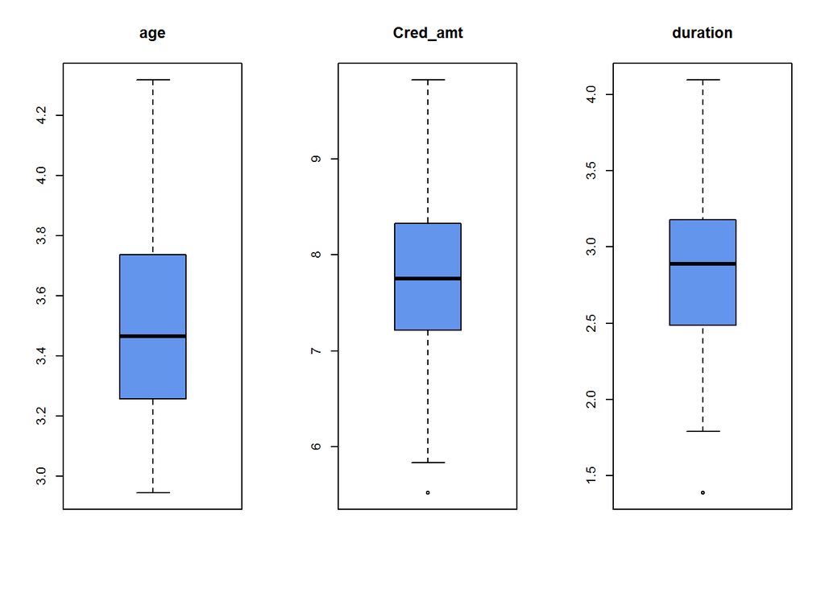

```r
par(mfrow=c(1,3))
boxplot(train$age,col ="cornflowerblue",main="age")
boxplot(train$Cred_amt,col ="cornflowerblue",main="Cred_amt")
boxplot(train$duration,col ="cornflowerblue",main="duration")
```

After logarithmic tranformation there is reduction in skewness in features, which indirectly treats outlier problem

## Standardisation

```r
train$duration <- scale(train$duration)
train$age <- scale(train$age)
train$Cred_amt <- scale(train$Cred_amt)
validation$age <- scale(validation$age)
validation$duration <- scale(validation$duration)
validation$Cred_amt <- scale(validation$Cred_amt)
```

Scaling of above three attributes will take care of outliers while building models.

## Convetring categorical into numeric variables

```r
train_new<-train
train_new$check.acc.<-ifelse(train_new$check.acc.=='A11',0,ifelse(train_new$check.acc.=='A12',1,ifelse(train_new$check.acc.=='A13',2,3)))

train_new$cred_hist.<-ifelse(train_new$cred_hist.=='A30',0,ifelse(train_new$cred_hist.=='A31',1,ifelse(train_new$cred_hist.=='A32',2,ifelse(train_new$cred_hist.=="A33",3,4))))
table(train_new$cred_hist.)
```

```
##
##   0   1   2   3   4
##  20  26 303  49 176
```

```r
train_new$Purpose<-ifelse(train_new$Purpose=='A40',0,ifelse(train_new$Purpose=='A41',1,ifelse(train_new$Purpose=='A410',2,ifelse(train_new$Purpose=="A42",3,ifelse(train_new$Purpose=='A43',4,ifelse(train_new$Purpose=='A44',5,ifelse(train_new$Purpose=='A45',6,ifelse(train_new$Purpose=='A46',7,ifelse(train_new$Purpose=='A48',8,9)))))))))
table(train_new$Purpose)
```

```
##
##   0   1   2   3   4   5   6   7   8   9
## 140  55   7 104 167   7   9  30   3  52
```

```r
train_new$saving_bond <-  ifelse(train_new$saving_bond=='A61',0,ifelse(train_new$saving_bond=='A62',1,ifelse(train_new$saving_bond=='A63',2,ifelse(train_new$saving_bond=="A64",3,4))))
table(train_new$saving_bond)
```

```
##
##   0   1   2   3   4
## 354  56  32  25 107
```

```r
train_new$employ_since <- ifelse(train_new$employ_since=='A71',0,ifelse(train_new$employ_since=='A72',1,ifelse(train_new$employ_since=='A73',2,ifelse(train_new$employ_since=="A74",3,4))))
table(train_new$employ_since)
```

```
##
##   0   1   2   3   4
##  41 109 194  95 135
```

```r
train_new$personal_status <- ifelse(train_new$personal_status=='A91',0,ifelse(train_new$personal_status=='A92',1,ifelse(train_new$personal_status=='A93',2,3)))
table(train_new$personal_status)
```

```
##
##   0   1   2   3
##  25 183 311  55
```

```r
train_new$property. <- ifelse(train_new$property.=='A121',0,ifelse(train_new$property.=='A122',1,ifelse(train_new$property.=='A123',2,3)))
table(train_new$property.)
```

```
##
##   0   1   2   3
## 154 127 198  95
```

```r
train_new$other_install_plans <-ifelse(train_new$other_install_plans=='A141',0,ifelse(train_new$other_install_plans=='A142',1,2))
table(train_new$other_install_plans)
```

```
##
##   0   1   2
##  91  23 460
```

```r
train_new$housing. <- ifelse(train_new$housing.=='A151',0,ifelse(train_new$housing.=='A152',1,2))
table(train_new$housing.)
```

```
##
##   0   1   2
##  94 407  73
```

```r
 train_new$job <- ifelse(train_new$job=='A171',0,ifelse(train_new$job=='A172',1,ifelse(train_new$job=='A173',2,3)))
table(train_new$job)
```

```
##
##   0   1   2   3
##  12 111 361  90
```

```r
train_new$telephone <- ifelse(train_new$telephone=='A191',0,1)
table(train_new$telephone)
```

```
##
##   0   1
## 327 247
```

```r
 train_new$foreign_worker <- ifelse(train_new$foreign_worker=='A201',0,1)
 table(train_new$foreign_worker)
```

```
##
##   0   1
## 555  19
```

```r
valid_new <- validation

valid_new$check.acc.<-ifelse(valid_new$check.acc.=='A11',0,ifelse(valid_new$check.acc.=='A12',1,ifelse(valid_new$check.acc.=='A13',2,3)))

valid_new$cred_hist.<-ifelse(valid_new$cred_hist.=='A30',0,ifelse(valid_new$cred_hist.=='A31',1,ifelse(valid_new$cred_hist.=='A32',2,ifelse(valid_new$cred_hist.=="A33",3,4))))
table(valid_new$cred_hist.)
```

```
##
##   0   1   2   3   4
##  11   9 110  19  58
```

```r
valid_new$Purpose<-ifelse(valid_new$Purpose=='A40',0,ifelse(valid_new$Purpose=='A41',1,ifelse(valid_new$Purpose=='A410',2,ifelse(valid_new$Purpose=="A42",3,ifelse(valid_new$Purpose=='A43',4,ifelse(valid_new$Purpose=='A44',5,ifelse(valid_new$Purpose=='A45',6,ifelse(valid_new$Purpose=='A46',7,ifelse(valid_new$Purpose=='A48',8,9)))))))))
table(valid_new$Purpose)
```

```
##
##  0  1  2  3  4  5  6  7  8  9
## 42 30  2 36 54  2  8 12  3 18
```

```r
valid_new$saving_bond <-  ifelse(valid_new$saving_bond=='A61',0,ifelse(valid_new$saving_bond=='A62',1,ifelse(valid_new$saving_bond=='A63',2,ifelse(valid_new$saving_bond=="A64",3,4))))
table(valid_new$saving_bond)
```

```
##
##   0   1   2   3   4
## 120  21  15  12  39
```

```r
valid_new$employ_since <- ifelse(valid_new$employ_since=='A71',0,ifelse(valid_new$employ_since=='A72',1,ifelse(valid_new$employ_since=='A73',2,ifelse(valid_new$employ_since=="A74",3,4))))
table(valid_new$employ_since)
```

```
##
##  0  1  2  3  4
##  8 38 66 41 54
```

```r
valid_new$personal_status <- ifelse(valid_new$personal_status=='A91',0,ifelse(valid_new$personal_status=='A92',1,ifelse(valid_new$personal_status=='A93',2,3)))
table(valid_new$personal_status)
```

```
##
##   0   1   2   3
##  10  72 112  13
```

```r
valid_new$property. <- ifelse(valid_new$property.=='A121',0,ifelse(valid_new$property.=='A122',1,ifelse(valid_new$property.=='A123',2,3)))
table(valid_new$property.)
```

```
##
##  0  1  2  3
## 58 51 74 24
```

```r
valid_new$other_install_plans <-ifelse(valid_new$other_install_plans=='A141',0,ifelse(valid_new$other_install_plans=='A142',1,2))
table(valid_new$other_install_plans)
```

```
##
##   0   1   2
##  25   8 174
```

```r
valid_new$housing. <- ifelse(valid_new$housing.=='A151',0,ifelse(valid_new$housing.=='A152',1,2))
table(valid_new$housing.)
```

```
##
##   0   1   2
##  42 151  14
```

```r
valid_new$job <- ifelse(valid_new$job=='A171',0,ifelse(valid_new$job=='A172',1,ifelse(valid_new$job=='A173',2,3)))
table(valid_new$job)
```

```
##
##   0   1   2   3
##   3  43 136  25
```

```r
valid_new$telephone <- ifelse(valid_new$telephone=='A191',0,1)
table(valid_new$telephone)
```

```
##
##   0   1
## 134  73
```

```r
valid_new$foreign_worker <- ifelse(valid_new$foreign_worker=='A201',0,1)
table(valid_new$foreign_worker)
```

```
##
##   0   1
## 200   7
```

```r
class(train_new$age)
```

```
## [1] "matrix"
```

## Logistic Regression

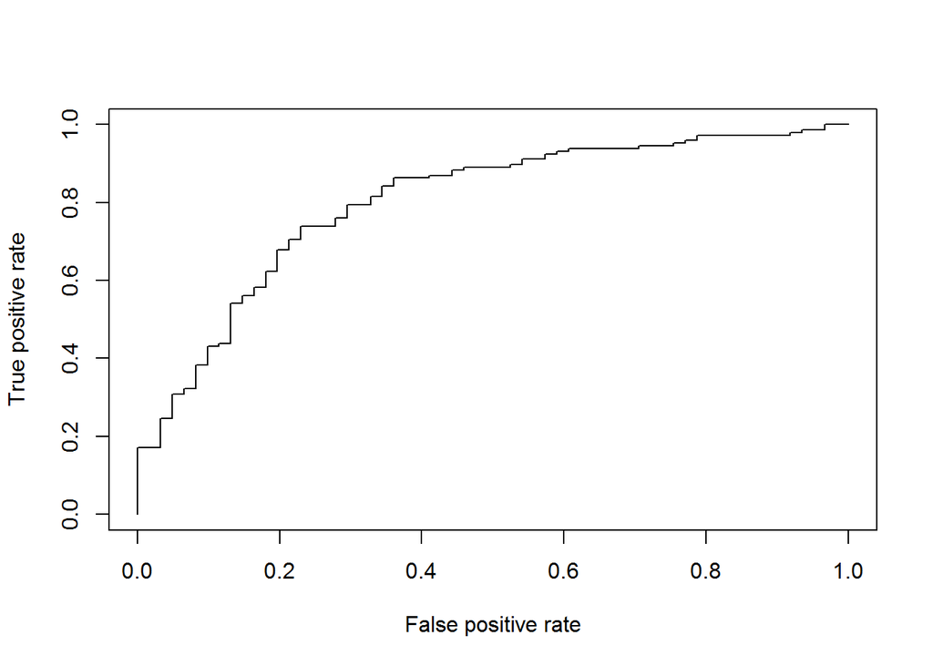

```r
model_fr<- glm(status~.,train_new,family = binomial)
 valid_new$status.p <- predict(model_fr,valid_new,type = "response")
 pred_fit <- prediction(valid_new$status.p,valid_new$status)
 pred_perf <- performance(pred_fit,"tpr","fpr")
 plot(pred_perf)
```

```r
 Auc_value <- performance(pred_fit,measure = "auc")@y.values[[1]]
 cat("AUC:",Auc_value)
```

```
## AUC: 0.8008084
```

```r
 head(valid_new$status.p)
```

```
## [1] 0.5184704 0.4185950 0.3599103 0.8534623 0.6196179 0.8037347
```

- Confusion matrix for evaluating our model accuracy

```r
valid_new$status.p <- ifelse(valid_new$status.p>0.5,1,0)
valid_new$status <-as.factor(valid_new$status)
valid_new$status.p <-as.factor(valid_new$status.p)
con_mat <- table(valid_new$status,valid_new$status.p)
model_score <-sum(diag(con_mat))/sum(con_mat)
 model_score
```

```
## [1] 0.7826087
```

```r
mat <-caret::confusionMatrix(valid_new$status,valid_new$status.p)
mat
```

```
## Confusion Matrix and Statistics
##
##           Reference
## Prediction   0   1
##          0  33  28
##          1  17 129
##
##                Accuracy : 0.7826
##                  95% CI : (0.7201, 0.8368)
##     No Information Rate : 0.7585
##     P-Value [Acc > NIR] : 0.2345
##
##                   Kappa : 0.4481
##  Mcnemar's Test P-Value : 0.1360
##
##             Sensitivity : 0.6600
##             Specificity : 0.8217
##          Pos Pred Value : 0.5410
##          Neg Pred Value : 0.8836
##              Prevalence : 0.2415
##          Detection Rate : 0.1594
##    Detection Prevalence : 0.2947
##       Balanced Accuracy : 0.7408
##
##        'Positive' Class : 0
##
```

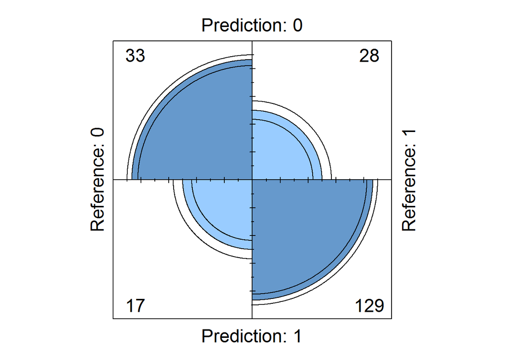

```r
fourfoldplot(mat$table)
```

## Let’s analyse the model

```r
summary(model_fr)
```

```
##
## Call:
## glm(formula = status ~ ., family = binomial, data = train_new)
##
## Deviance Residuals:
##     Min       1Q   Median       3Q      Max
## -2.5447  -0.8055   0.4335   0.7239   1.9161
##
## Coefficients:
##                      Estimate Std. Error z value Pr(>|z|)
## (Intercept)         -1.056743   0.822051  -1.285  0.19862
## check.acc.           0.628214   0.092561   6.787 1.14e-11 ***
## duration            -0.447563   0.156873  -2.853  0.00433 **
## cred_hist.           0.323398   0.114035   2.836  0.00457 **
## Purpose              0.045401   0.040733   1.115  0.26501
## Cred_amt            -0.087777   0.167550  -0.524  0.60036
## saving_bond          0.183833   0.074229   2.477  0.01327 *
## employ_since         0.234071   0.092441   2.532  0.01134 *
## Installment_rate    -0.223016   0.113374  -1.967  0.04917 *
## personal_status      0.229816   0.152081   1.511  0.13075
## other_debtorsA102   -0.391826   0.472326  -0.830  0.40678
## other_debtorsA103    0.817263   0.526464   1.552  0.12058
## residence_since     -0.052786   0.104938  -0.503  0.61495
## property.           -0.095159   0.124080  -0.767  0.44313
## age                  0.125492   0.126449   0.992  0.32098
## other_install_plans  0.309836   0.138589   2.236  0.02537 *
## housing.             0.083211   0.224930   0.370  0.71143
## no.of_exist_cred    -0.094670   0.202912  -0.467  0.64082
## job                  0.090767   0.186894   0.486  0.62721
## dependents          -0.673387   0.314539  -2.141  0.03228 *
## telephone            0.008842   0.243172   0.036  0.97100
## foreign_worker       1.677774   0.849975   1.974  0.04839 *
## ---
## Signif. codes:  0 '***' 0.001 '**' 0.01 '*' 0.05 '.' 0.1 ' ' 1
##
## (Dispersion parameter for binomial family taken to be 1)
##
##     Null deviance: 713.99  on 573  degrees of freedom
## Residual deviance: 551.55  on 552  degrees of freedom
## AIC: 595.55
##
## Number of Fisher Scoring iterations: 5
```

- After looking at the z values of each attributes, we can say that some of the attributes may be overfitting the data or of negligible importance, so it is better to remove them.

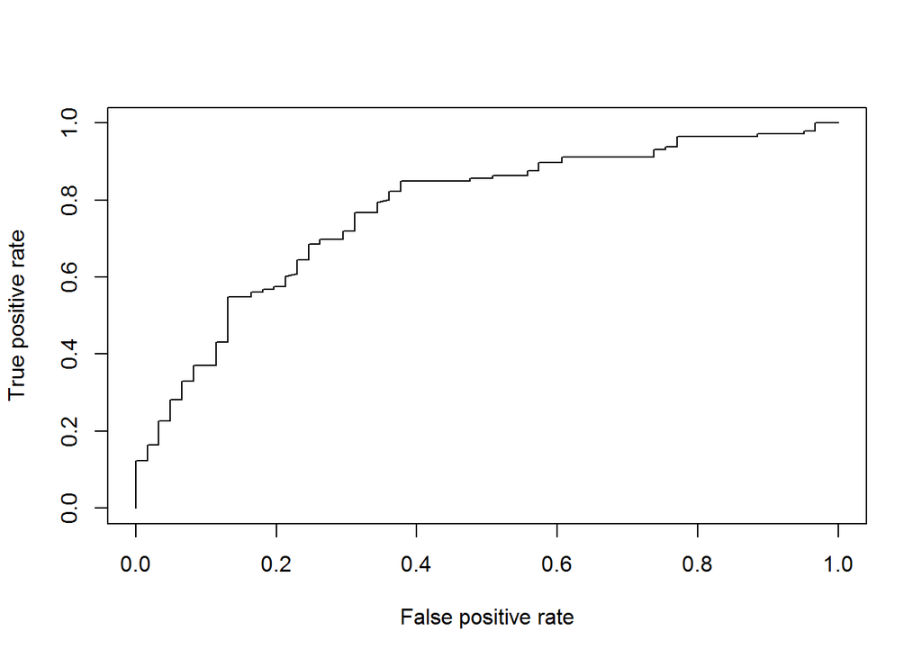

```r
model_fr<- glm(status~cred_hist.+saving_bond+duration+Installment_rate+check.acc.+employ_since+other_install_plans+foreign_worker+dependents+personal_status,train_new,family = binomial)
 valid_new$status.p <- predict(model_fr,valid_new,type = "response")
 pred_fit <- prediction(valid_new$status.p,valid_new$status)
 pred_perf <- performance(pred_fit,"tpr","fpr")
 plot(pred_perf)
```

```r
 Auc_value <- performance(pred_fit,measure = "auc")@y.values[[1]]
 cat("AUC:",Auc_value)
```

```
## AUC: 0.7730743
```

- Let’s see the summary of the model

```r
summary(model_fr)
```

```
##
## Call:
## glm(formula = status ~ cred_hist. + saving_bond + duration +
##     Installment_rate + check.acc. + employ_since + other_install_plans +
##     foreign_worker + dependents + personal_status, family = binomial,
##     data = train_new)
##
## Deviance Residuals:
##     Min       1Q   Median       3Q      Max
## -2.5181  -0.8362   0.4439   0.7542   1.8393
##
## Coefficients:
##                     Estimate Std. Error z value Pr(>|z|)
## (Intercept)         -1.08125    0.60715  -1.781  0.07494 .
## cred_hist.           0.28552    0.10266   2.781  0.00542 **
## saving_bond          0.16661    0.07263   2.294  0.02180 *
## duration            -0.52662    0.11178  -4.711 2.46e-06 ***
## Installment_rate    -0.18351    0.09507  -1.930  0.05358 .
## check.acc.           0.63690    0.09038   7.047 1.83e-12 ***
## employ_since         0.25294    0.08827   2.866  0.00416 **
## other_install_plans  0.29430    0.13435   2.191  0.02848 *
## foreign_worker       1.52642    0.82974   1.840  0.06582 .
## dependents          -0.65405    0.30559  -2.140  0.03233 *
## personal_status      0.21423    0.14891   1.439  0.15024
## ---
## Signif. codes:  0 '***' 0.001 '**' 0.01 '*' 0.05 '.' 0.1 ' ' 1
##
## (Dispersion parameter for binomial family taken to be 1)
##
##     Null deviance: 713.99  on 573  degrees of freedom
## Residual deviance: 560.22  on 563  degrees of freedom
## AIC: 582.22
##
## Number of Fisher Scoring iterations: 5
```

The AIC value for this model decreased, which is a good sign

Confusion matrix for evaluating our model accuracy

```r
valid_new$status.p <- ifelse(valid_new$status.p>0.5,1,0)
con_mat <- table(valid_new$status,valid_new$status.p)
model_score <-sum(diag(con_mat))/sum(con_mat)
 model_score
```

```
## [1] 0.7487923
```

```r
 valid_new$status <-as.factor(valid_new$status)
valid_new$status.p <-as.factor(valid_new$status.p)
mat <- caret::confusionMatrix(valid_new$status,valid_new$status.p)
mat
```

```
## Confusion Matrix and Statistics
##
##           Reference
## Prediction   0   1
##          0  30  31
##          1  21 125
##
##                Accuracy : 0.7488
##                  95% CI : (0.684, 0.8063)
##     No Information Rate : 0.7536
##     P-Value [Acc > NIR] : 0.6005
##
##                   Kappa : 0.3654
##  Mcnemar's Test P-Value : 0.2120
##
##             Sensitivity : 0.5882
##             Specificity : 0.8013
##          Pos Pred Value : 0.4918
##          Neg Pred Value : 0.8562
##              Prevalence : 0.2464
##          Detection Rate : 0.1449
##    Detection Prevalence : 0.2947
##       Balanced Accuracy : 0.6948
##
##        'Positive' Class : 0
##
```

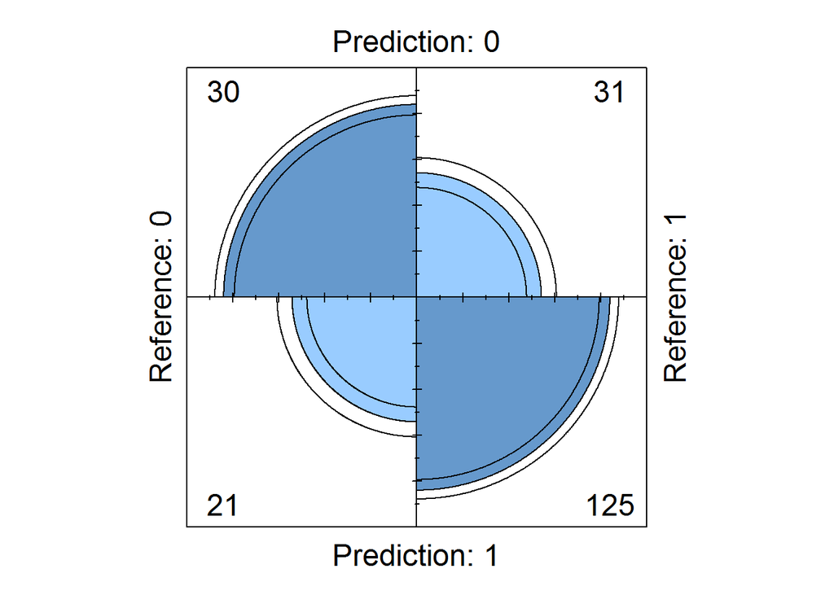

```r
fourfoldplot(mat$table)
```

- Though our accuracy went down a little, but including more features can cause overfitting so good to consider less features.

## 2. Decision tree

```r
model_dt<- rpart(status~.,train,method = "class")
validation$status.p <- predict(model_dt,validation,type = "class")
 con_mat <- table(validation$status,validation$status.p)
model_score <-sum(diag(con_mat))/sum(con_mat)
 model_score
```

```
## [1] 0.7149758
```

```r
 validation$status <-as.factor(validation$status)
validation$status.p <-as.factor(validation$status.p)
p1 <-caret::confusionMatrix(validation$status,validation$status.p)
p1
```

```
## Confusion Matrix and Statistics
##
##           Reference
## Prediction   0   1
##          0  29  32
##          1  27 119
##
##                Accuracy : 0.715
##                  95% CI : (0.6483, 0.7754)
##     No Information Rate : 0.7295
##     P-Value [Acc > NIR] : 0.7108
##
##                   Kappa : 0.2976
##  Mcnemar's Test P-Value : 0.6025
##
##             Sensitivity : 0.5179
##             Specificity : 0.7881
##          Pos Pred Value : 0.4754
##          Neg Pred Value : 0.8151
##              Prevalence : 0.2705
##          Detection Rate : 0.1401
##    Detection Prevalence : 0.2947
##       Balanced Accuracy : 0.6530
##
##        'Positive' Class : 0
##
```

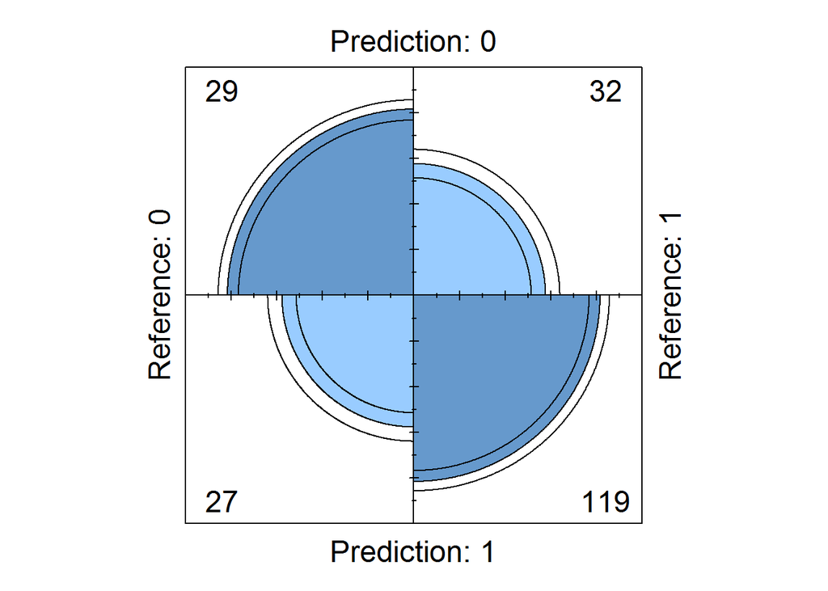

```r
fourfoldplot(p1$table)
```

```r
 summary(model_dt)
```

```
## Call:
## rpart(formula = status ~ ., data = train, method = "class")
##   n= 574
##
##           CP nsplit rel error    xerror       xstd
## 1 0.07222222      0 1.0000000 1.0000000 0.06175269
## 2 0.05555556      2 0.8555556 1.0500000 0.06255079
## 3 0.05000000      3 0.8000000 1.0444444 0.06246606
## 4 0.04444444      4 0.7500000 1.0111111 0.06193702
## 5 0.01851852      5 0.7055556 1.0111111 0.06193702
## 6 0.01666667      8 0.6500000 0.8722222 0.05933206
## 7 0.01388889      9 0.6333333 0.8444444 0.05872859
## 8 0.01111111     11 0.6055556 0.8444444 0.05872859
## 9 0.01000000     13 0.5833333 0.8666667 0.05921367
##
## Variable importance
##       check.acc.       cred_hist.          Purpose      saving_bond
##               22               13                9                9
##         Cred_amt              age        property.         duration
##                7                6                6                6
##     employ_since no.of_exist_cred  personal_status              job
##                6                5                3                2
## Installment_rate        telephone    other_debtors  residence_since
##                1                1                1                1
##
## Node number 1: 574 observations,    complexity param=0.07222222
##   predicted class=1  expected loss=0.3135889  P(node) =1
##     class counts:   180   394
##    probabilities: 0.314 0.686
##   left son=2 (297 obs) right son=3 (277 obs)
##   Primary splits:
##       check.acc. splits as  LLRR, improve=30.646890, (0 missing)
##       cred_hist. splits as  LLRRR, improve=10.040660, (0 missing)
##       Cred_amt   < 2.038737   to the right, improve= 7.545145, (0 missing)
##       duration   < 0.4403612  to the right, improve= 7.000676, (0 missing)
##       Purpose    splits as  LRLLRRRLRL, improve= 6.658535, (0 missing)
##   Surrogate splits:
##       cred_hist.       splits as  LLLRR, agree=0.610, adj=0.191, (0 split)
##       saving_bond      splits as  LLRRR, agree=0.598, adj=0.166, (0 split)
##       employ_since     splits as  LLRLR, agree=0.578, adj=0.126, (0 split)
```

[output cut: 249 more lines]

```
##       employ_since    splits as  -RLRL, agree=0.667, adj=0.333, (0 split)
##       residence_since < 2.5        to the right, agree=0.667, adj=0.333, (0 split)
##       age             < -0.6629139 to the right, agree=0.667, adj=0.333, (0 split)
##       telephone       splits as  RL, agree=0.667, adj=0.333, (0 split)
##       saving_bond     splits as  RL--L, agree=0.625, adj=0.250, (0 split)
##
## Node number 714: 12 observations
##   predicted class=0  expected loss=0.4166667  P(node) =0.02090592
##     class counts:     7     5
##    probabilities: 0.583 0.417
##
## Node number 715: 12 observations
##   predicted class=1  expected loss=0.1666667  P(node) =0.02090592
##     class counts:     2    10
##    probabilities: 0.167 0.833
```

Looking at summary there are some attributes that have less number of significance. So let’s remove them.

```r
model_dt<- rpart(status~cred_hist.+saving_bond+duration+check.acc.+employ_since+personal_status+age+Cred_amt+Purpose+property.+no.of_exist_cred,train, method = 'class')
validation$status.p <- predict(model_dt,validation,type = "class")
 con_mat <- table(validation$status,validation$status.p)
model_score <-sum(diag(con_mat))/sum(con_mat)
 model_score
```

```
## [1] 0.7294686
```

```r
 validation$status <-as.factor(validation$status)
validation$status.p <-as.factor(validation$status.p)
p1 <-caret::confusionMatrix(validation$status,validation$status.p)
p1
```

```
## Confusion Matrix and Statistics
##
##           Reference
## Prediction   0   1
##          0  29  32
##          1  24 122
##
##                Accuracy : 0.7295
##                  95% CI : (0.6635, 0.7887)
##     No Information Rate : 0.744
##     P-Value [Acc > NIR] : 0.7144
##
##                   Kappa : 0.3234
##  Mcnemar's Test P-Value : 0.3496
##
##             Sensitivity : 0.5472
##             Specificity : 0.7922
##          Pos Pred Value : 0.4754
##          Neg Pred Value : 0.8356
##              Prevalence : 0.2560
##          Detection Rate : 0.1401
##    Detection Prevalence : 0.2947
##       Balanced Accuracy : 0.6697
##
##        'Positive' Class : 0
##
```

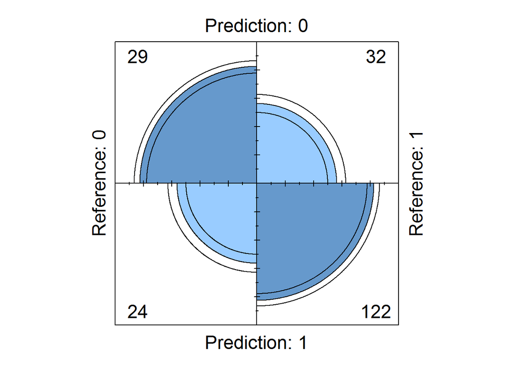

```r
fourfoldplot(p1$table)
```

The score increases a little bit, that means the attributes we removed were overfitting the model.

## 3 Random_Forest

For random forest we need to convert features class to factors and perform classification analysis.

```r
COl <- c(train_new$check.acc., train_new$cred_hist., train_new$Purpose ,train_new$saving_bond, train_new$personal_status, train_new$other_debtors,train_new$property.,train_new$other_install_plans,train_new$housing.,train_new$job,train_new$telephone,train_new$foreign_worker,train_new$employ_since,train_new$status)

for (i in col){
  i <- as.factor(i)
}
train_new$age <- as.integer(train_new$age)
train_new$other_debtors <- as.factor(train_new$other_debtors)
str(train_new)
```

```
## 'data.frame':    574 obs. of  21 variables:
##  $ check.acc.         : num  0 1 3 0 0 3 1 3 1 1 ...
##  $ duration           : num [1:574, 1] -1.845 1.694 -0.665 1.467 0.514 ...
##   ..- attr(*, "scaled:center")= num 2.88
##   ..- attr(*, "scaled:scale")= num 0.588
##  $ cred_hist.         : num  4 2 4 2 3 2 2 2 4 2 ...
##  $ Purpose            : num  4 4 7 3 0 7 1 4 0 4 ...
##  $ Cred_amt           : num [1:574, 1] -0.935 1.115 -0.199 1.469 0.863 ...
##   ..- attr(*, "scaled:center")= num 7.81
##   ..- attr(*, "scaled:scale")= num 0.794
##  $ saving_bond        : num  4 0 0 0 0 4 0 3 0 0 ...
##  $ employ_since       : num  4 2 3 3 2 2 2 3 0 2 ...
##  $ Installment_rate   : int  4 2 2 2 3 2 2 2 4 1 ...
##  $ personal_status    : num  2 1 2 2 2 2 2 0 3 1 ...
##  $ other_debtors      : Factor w/ 3 levels "A101","A102",..: 1 1 1 3 1 1 1 1 1 1 ...
##  $ residence_since    : int  4 2 3 4 4 4 2 4 2 1 ...
##  $ property.          : num  0 0 0 1 3 3 2 0 2 2 ...
##  $ age                : int  2 -1 1 0 1 0 0 1 0 -1 ...
##  $ other_install_plans: num  2 2 2 2 2 2 2 2 2 2 ...
##  $ housing.           : num  1 1 1 2 2 2 0 1 1 1 ...
##  $ no.of_exist_cred   : int  2 1 1 1 2 1 1 1 2 1 ...
##  $ job                : num  2 2 1 2 2 1 3 1 3 2 ...
##  $ dependents         : int  1 1 2 2 2 2 1 1 1 1 ...
##  $ telephone          : num  1 0 0 0 0 1 1 0 0 1 ...
##  $ foreign_worker     : num  0 0 0 0 0 0 0 0 0 0 ...
##  $ status             : num  1 0 1 1 0 1 1 1 0 1 ...
```

Building random forest model

```
## mtry = 7  OOB error = 0.002239854
## Searching left ...
```

```
## mtry = 6     OOB error = 0.004282395
## -0.911908 0.01
## Searching right ...
```

```
## mtry = 8     OOB error = 0.001210157
## 0.4597161 0.01
```

```
## mtry = 9     OOB error = 0.00132233
## -0.09269318 0.01
```

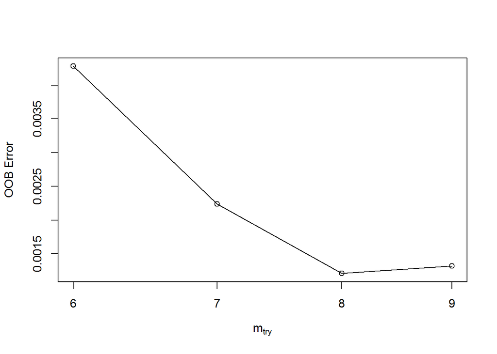

```r
tuning <- tuneRF(train_new,train_new$status,stepFactor = 1.2,improve = 0.01,trace = T,plot = T)
```

```r
train_new$status <- as.factor(train_new$status)
model_rf <-  randomForest(status~.,train_new,importance = T,type = 'classification')
```

## Analyse the features importance

```r
tuning
```

```
##   mtry    OOBError
## 6    6 0.004282395
## 7    7 0.002239854
## 8    8 0.001210157
## 9    9 0.001322330
```

```r
model_rf
```

```
##
## Call:
##  randomForest(formula = status ~ ., data = train_new, importance = T,      type = "classification")
##                Type of random forest: classification
##                      Number of trees: 500
## No. of variables tried at each split: 4
##
##         OOB estimate of  error rate: 25.09%
## Confusion matrix:
##    0   1 class.error
## 0 78 102   0.5666667
## 1 42 352   0.1065990
```

```r
model_rf$importance
```

```
##                                 0             1 MeanDecreaseAccuracy
## check.acc.           0.0697130818  0.0290326337         4.166401e-02
## duration             0.0097956705  0.0187499081         1.593630e-02
## cred_hist.           0.0168060877  0.0124929244         1.381646e-02
## Purpose              0.0029502965  0.0014429095         1.816551e-03
## Cred_amt             0.0072850835  0.0116104548         1.035693e-02
## saving_bond          0.0070090481  0.0021292662         3.599591e-03
## employ_since         0.0100556252  0.0059581183         7.246517e-03
## Installment_rate     0.0009974951  0.0045269029         3.451106e-03
## personal_status      0.0035632119 -0.0012814986         2.150148e-04
## other_debtors        0.0024639215  0.0019979649         2.138855e-03
## residence_since     -0.0025610619  0.0011982905         4.072569e-05
## property.           -0.0032322948  0.0062002601         3.259074e-03
## age                 -0.0007076699  0.0010798994         4.533475e-04
## other_install_plans  0.0002972904  0.0024580303         1.798244e-03
## housing.            -0.0005787420  0.0019871899         1.201994e-03
## no.of_exist_cred    -0.0009629382  0.0008461207         2.799305e-04
## job                  0.0006919287  0.0039766331         2.983845e-03
## dependents          -0.0003782908  0.0003973138         1.736158e-04
## telephone           -0.0024582834 -0.0008209537        -1.319307e-03
## foreign_worker       0.0001594597  0.0009013443         6.764386e-04
##                     MeanDecreaseGini
## check.acc.                 31.164715
## duration                   25.406146
## cred_hist.                 15.360828
## Purpose                    16.247710
## Cred_amt                   35.350317
## saving_bond                11.049360
## employ_since               14.822021
## Installment_rate           10.932667
## personal_status             9.746272
## other_debtors               5.344734
## residence_since            10.016217
## property.                  11.518277
## age                         8.159170
## other_install_plans         7.079854
## housing.                    6.511282
## no.of_exist_cred            5.335215
## job                         8.941492
## dependents                  3.828470
## telephone                   5.095278
## foreign_worker              1.432180
```

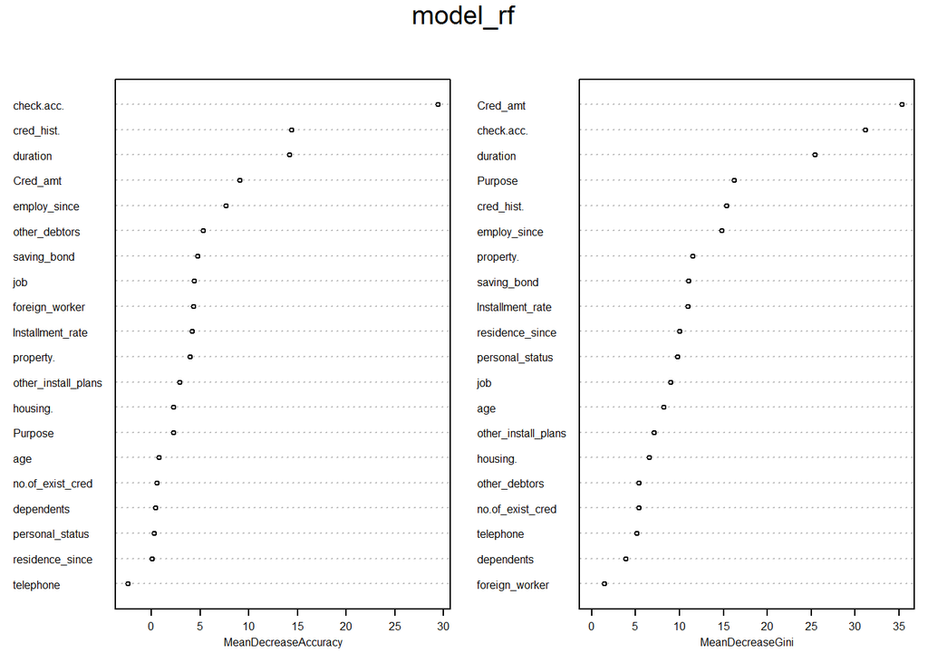

```r
varImpPlot(model_rf,cex= 0.5)
```

```r
COl <- c(valid_new$check.acc., valid_new$cred_hist., valid_new$Purpose ,valid_new$saving_bond, valid_new$personal_status, valid_new$other_debtors,valid_new$property.,valid_new$other_install_plans,valid_new$housing.,valid_new$job,valid_new$telephone,valid_new$foreign_worker,valid_new$employ_since,valid_new$status)

for (i in col){
  i <- as.factor(i)
}
valid_new$other_debtors <- as.factor(valid_new$other_debtors)
pred <- predict(model_rf,valid_new,type = "class")
pred <- as.factor(pred)
valid_new$status <- as.factor(valid_new$status)
con_mat <- caret::confusionMatrix(table(valid_new$status,pred))
con_mat
```

```
## Confusion Matrix and Statistics
##
##    pred
##       0   1
##   0  29  32
##   1  12 134
##
##                Accuracy : 0.7874
##                  95% CI : (0.7254, 0.8411)
##     No Information Rate : 0.8019
##     P-Value [Acc > NIR] : 0.732796
##
##                   Kappa : 0.4347
##  Mcnemar's Test P-Value : 0.004179
##
##             Sensitivity : 0.7073
##             Specificity : 0.8072
##          Pos Pred Value : 0.4754
##          Neg Pred Value : 0.9178
##              Prevalence : 0.1981
##          Detection Rate : 0.1401
##    Detection Prevalence : 0.2947
##       Balanced Accuracy : 0.7573
##
##        'Positive' Class : 0
##
```

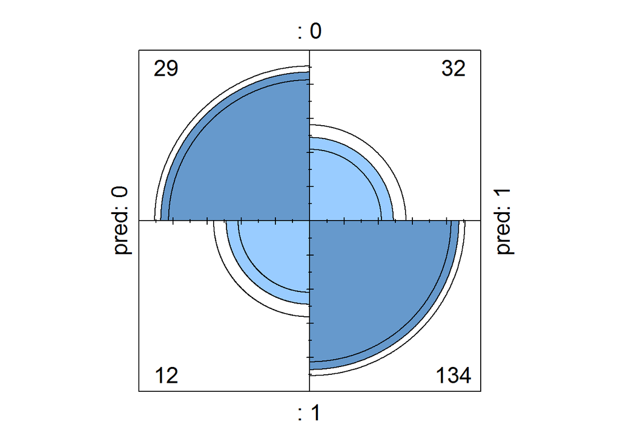

```r
fourfoldplot(con_mat$table)
```

# Observation

**Random_Forest > logistic model > decision tree**